# Finales Projekt "Fake News Analyse"

- Vorgelegt von: Marc Friz (40654), Botan Babat (40472), Nadja Herrmann (40523)
- Vorgelegt bei: Prof. Dr. Johannes Maucher
- Vorgelegt am: 05.01.2021

### 1. Einleitung

Heutzutage werden Nachrichten über unterschiedliche Medien an die Masse verteilt. Medien sind zum Beispiel die sozialen Medien oder auch Online-Blogs. Einerseits führen der einfache Zugang und die schnelle Verbreitung von Nachrichten dazu, dass viele Menschen die Nachrichten konsumieren. Auf der anderen Seite wird dadurch die schnelle Verbreitung von "Fake News" begünstigt.

Fake News sind Nachrichten von geringer Qualität und mit absichtlich falschen Informationen. Fake News sind keine Neuheit. Vor dem digitalen Zeitalter wurden sie hauptsächlich durch Boulevardjournalismus verbreitet. Die Verbreitung von Fake News hängt mit der Verfügbarkeit von digitalen Werkzeugen der Massenmedien zusammen. Die weite Verbreitung von Fake News kann negative Auswirkungen auf Individuen und die Gesellschaft haben. Daher ist die Erkennung solcher Nachrichten von hoher Relevanz (Shu et al, 2017).

#### 1.1 Problemstellung und Ziel der Arbeit

Die Folgen der Verbreitung von Fake News können von bloßem Ärgernis bis hin zur Beeinflussung und Irreführung von Gesellschaften oder sogar Nationen reichen. Es gibt eine Vielzahl von Ansätzen, um Fake News zu identifizieren. Viele bauen auf die Verwendung von Lernalgorithmen auf.

In diesem Projekt werden wir die Hauptprobleme bei der Erkennung von Fake News analysieren und diskutieren. Wir werden mittels statistischen Methoden Fake News untersuchen und diese mit True News vergleichen. Mit den Ergebnissen der Analyse werden wir die manuelle Vorgehensweise zur Erkennung der Fake News bewerten.

#### 1.2 Aufbau der Arbeit

Diese Arbeit beschreibt im ersten Teil nach einer kurzen Motivation und Problemstellung das Ziel der Arbeit. In Kapitel zwei wird die Datenbeschaffung beschrieben. In Kapitel drei wird die Notwendigkeit der Python Pakete beschrieben, die im nächsten Schritt importiert werden. In Kapitel vier werden die drei einzelnen Datensätze kurz beschrieben und zu einem Datensatz zusammengefasst. Im nächsten Kapitel wird der finale Datensatz bereinigt und für die darauffolgende Analyse vorbereitet. In Kapitel sechs wird die Datenanalyse beschrieben. Teil hiervon ist eine detaillierte Beschreibung. Des Weiteren werden unterschiedliche Analysemöglichkeiten aufgezeigt. Hierzu zählen die Betrachtung der Worthäufigkeiten, N-Gramm Ranking und die Association Rule. Im darauffolgenden Kapitel folgt die Interpretation der Ergebnisse. Der Abschluss der Arbeit ist eine Schlussbetrachtung mit einem kurzen Ausblick.

#### 1.3 Literaturrecherche

Der Zweck dieser Arbeit ist es, Ansätze zur Identifizierung von Fake News zu betrachten. Dazu wurde eine Literaturrecherche durchgeführt. In diesem Abschnitt werden die verwendeten Suchbegriffe vorgestellt.

##### Suchbegriffe

- `'Fake News'`, ('Was sind Fake News', 'Synonyme für Fake News', 'Problemstellung Fake News', 'Auswirkungen und Folgen von Fake News')
- `'Fake News Detection'`, ('Approaches to identify Fake News', 'Approaches to identify missleaded News', 'Finding Fake News', 'Identify Fake News', 'Data Science Fake News Detection', 'machine learning fake news detection', )
- `'Text Mining'`, ('Natural Language Processing bei Fake News', 'Text mining Fake news', 'Text mining in Python3, 'Data Preparation', Data Exploration in Python', 'n-grams mit Python', 'Association Rule mit Python', 'Worthäufigkeiten analysieren mit Python', 'Word2Vec', 'Datenbereinigung mit Python', 'Data Cleaning in Python', 'Developing a Data Science Model to Predict Fake News', 'Using Random Forest, GridSearchCV, Python, and NLP for fake news detection', 'Stemming', 'Tokenizing', 'Eliminating Stopwords', 'Association Rule Mining via Apriori Algorithm in Python')

### 2. Datenbeschaffung

Für das Projekt werden bereits bestehende Datensätze herangezogen. Diese Datensätze entstehen aus unterschiedliche Quellen (Statista, Kaggle). Die Datensätze beinhalten Nachrichten von unterschiedlichen amerikanischen Nachrichtensendern. Des weiteren enthalten die Datensätze falsche Nachrichten (Fake Nachrichten). Diese Nachrichten sind falsch, da sich eine falsche/fehlerhafte Aussage darin befindet. Die Nachrichten sind in falsch und richtig gelabelt. Im weiteren Verlauf der Arbeit verwenden wir hierfür die englische Bezeichnung false/fake und true. Da der Fokus dieser Arbeit ist Besonderheiten der Fake Nachrichten zu identifizieren, um dadurch die Einteilung der Nachrichten automatisch durchführen zu können, werden schon bereits gelabelte Datensätze verwendet. Die Datensätze enthalten Artikel zu unterschiedlichen Kategorien. Die Hauptkategorie konzentriert sich auf politische Themen.

Die unterschiedlichen Datensätze wurden mit Hilfe der Suchmaschine "Google Dataset Search" gefunden.

#### 2.1 Datensatz 1: Kaggle

Der erste Datensatz wurde von Kaggle bezogen. Unter dem folgenden Link können die Daten sowie die dazugehörige Beschreibung eingesehen werden: [Link](https://www.kaggle.com/anthonyc1/fake-news-classifier-final-project). Der Datensatz enthält Text und Metadaten von 244 Webseiten, die von der BS Detector Chrome Extension von Daniel Sieradski als "Fake" markiert wurden. Bereitgstellt wurde dieser Datensatz von Meg Risdal (Produktmanagerin, Kaggle). Die "real" Daten wurden von unterschiedlichen Nachrichtenseiten gecrawlt und hinzugefügt. Die Quelle hierfür ist nicht vorhanden. Bereitgestellt und verarbeitet wurden die Daten von Anthony Chan. Siehe Link: [Link](https://www.kaggle.com/anthonyc1/fake-news-classifier-final-project).

#### 2.2 Datensatz 2: BuzzFeed-Webis Fake News Corpus 2016

Der Korpus umfasst den Output von 9 Verlagen in einer Woche kurz vor den US-Wahlen. Unter den ausgewählten Verlegern befinden sich 6 prominente überparteiliche Verleger und drei Mainstream-Verleger. Alle Verlage erhielten das blaue Häkchen von Facebook, was auf Authentizität und einen gehobenen Status innerhalb des Netzwerks hinweist. An sieben Wochentagen (19. bis 23. September sowie 26. und 27. September) wurde jeder Beitrag und jeder verlinkte Nachrichtenartikel der neun Verlage von professionellen Journalisten bei BuzzFeed auf Fakten geprüft. Insgesamt wurden 1.627 Artikel überprüft, 826 Mainstream, 256 linke und 545 rechte. Das Ungleichgewicht zwischen den Kategorien resultiert aus unterschiedlichen Veröffentlichungshäufigkeiten. Unter dem folgenden Link können die Daten sowie die dazugehörige Beschreibung eingesehen werden: [Link](https://zenodo.org/record/1239675#.X-724hZ76Ul)

### 3. Bibliotheken

#### 3.1 Einführung der benötigten Bibliotheken

- `Pandas` ist eine Python-Bibliothek, die zum Auswerten und Bearbeiten tabellarischer Daten gedacht ist. Pandas wird dazu benötigt um ein Objekt (Dataframe) zu erstellen und dieses komfortabel zu bearbeiten.
- `re` (Reguläre Ausdrücke) ist eine Standardbibliothek, die zahlreiche Funktionen und Methoden zum Arbeiten mit regulären Ausdrücken zur Verfügung stellt.
- Das `NLTK` (Natural Language Toolkit) ist eine Zusammenstellung von Bibliotheken und Programmen der Programmiersprache Python zur Verarbeitung der Daten in natürlicher Sprache.
- Das `String-Modul` enthält eine Reihe von Funktionen zur Verarbeitung von Standard-Python-Strings.
- Das Modul `UnicodeData` ermöglicht den Zugriff auf die Unicode-Zeichendatenbank (UCD), die Zeicheneigenschaften für alle Unicode-Zeichen definiert.
- `NumPy` ist eine Programmbibliothek, die eine einfache Handhabung von Vektoren, Matrizen oder generell großen mehrdimensionalen Arrays ermöglicht. Neben den Datenstrukturen bietet NumPy auch effizient implementierte Funktionen für numerische Berechnungen an.
- Das `XML Tool` wird verwendet um die hierarchisch Struktur einer XML-Datai auszulesen und ihren Inhalt zu extrahieren. Sie ermöglicht es gezielt nach Tags zu suchen welche als wichtig erachtet werden.
- Das Paket `mlxtend` wird für diverse datenwissenschaftliche Aufgaben verwendet. In dieser Projektarbeit wird das Paket für die Assoziationsregeln benötigt.

##### Visualisierung:

- `Matplotlib` ist eine Python-Bibliothek zum Plotten von 2D-Plots.
- `Bokeh` dient zu Visualisierung von Grafiken und Schaubildern.
- `Seaborn` ist eine Bibliothek zur Datenvisualisierung (Zeichnung von Grafiken), die auf matplotlib basiert.
- `Wordcloud` erstellt Bilder anhand der Häufigkeit von Worten.

#### 3.2 Bibliotheken importieren

```python
import numpy as np
import pandas as pd
import re
import string
from math import pi
import matplotlib.pyplot as plt
import seaborn as sns
import unicodedata

from os import listdir
from os.path import isfile, join
from collections import Counter

import nltk
from nltk import FreqDist, word_tokenize
from nltk.corpus import stopwords
from nltk.stem.snowball import SnowballStemmer

from wordcloud import WordCloud

from IPython.display import display
from bokeh.plotting import figure
from bokeh.io import output_notebook, show
from bokeh.models import ColumnDataSource, HoverTool, BasicTickFormatter
from bokeh.transform import cumsum

from mlxtend.frequent_patterns import association_rules
from mlxtend.preprocessing import TransactionEncoder
from mlxtend.frequent_patterns import apriori

from xml.dom import minidom
```

#### 3.3 Bibliotheken laden

```python
nltk.download('stopwords')
nltk.download('wordnet')
nltk.download('punkt')
```

```
True
```

```python
output_notebook()
```

### 4. Datenbereitstellung

Für die Datenbereitstellung werden zuerst alle drei Datensätze aufbereitet und im Anschluss in einem Datensatz zusammengefasst.

#### 4.1 Kaggle

Die extrahierten Daten werden in dem Basisformat.csv in JupyterNotebook geladen und als Dataframe dargestellt. Um einen Überblick der Daten zu erhalten wird im ersten Schritt die `.head()` Funktion von Panda angewendet, welche die ersten Zeilen des Dataframes ausgibt.

```python
news = pd.read_csv("../DataSet/news_dataset.csv", encoding="latin-1")
news.head()
```

|  | Unnamed: 0 | title | content | publication | label |
| --- | --- | --- | --- | --- | --- |
| 0 | 0 | Muslims BUSTED: They Stole Millions In Govât... | Print They should pay all the back all the mon... | 100percentfedup | fake |
| 1 | 1 | Re: Why Did Attorney General Loretta Lynch Ple... | Why Did Attorney General Loretta Lynch Plead T... | 100percentfedup | fake |
| 2 | 2 | BREAKING: Weiner Cooperating With FBI On Hilla... | Red State : \nFox News Sunday reported this mo... | 100percentfedup | fake |
| 3 | 3 | PIN DROP SPEECH BY FATHER OF DAUGHTER Kidnappe... | Email Kayla Mueller was a prisoner and torture... | 100percentfedup | fake |
| 4 | 4 | FANTASTIC! TRUMP'S 7 POINT PLAN To Reform Heal... | Email HEALTHCARE REFORM TO MAKE AMERICA GREAT ... | 100percentfedup | fake |

Durch die Funktion `.shape` werden die Dimensionen des Objekts angezeigt.

```python
news.shape
```

```
(28711, 5)
```

Das Objekt besteht aus 28711 Zeilen und 5 Spalten. Im nächsten Schritt werden die Spalten herausgegeben.

```python
news.columns
```

```
Index(['Unnamed: 0', 'title', 'content', 'publication', 'label'], dtype='object')
```

##### Schritt 1: Umbenennung der Spaltenbezeichnungen zur Vereinheitlichung der Basisdaten.

Zielformat CSV mit Spaltenbezeichnung: Title, text, source, veracity

```python
dfnews=news.rename(columns={'content':'text','publication':'source','label':'veracity'})
dfnews.head()
```

|  | Unnamed: 0 | title | text | source | veracity |
| --- | --- | --- | --- | --- | --- |
| 0 | 0 | Muslims BUSTED: They Stole Millions In Govât... | Print They should pay all the back all the mon... | 100percentfedup | fake |
| 1 | 1 | Re: Why Did Attorney General Loretta Lynch Ple... | Why Did Attorney General Loretta Lynch Plead T... | 100percentfedup | fake |
| 2 | 2 | BREAKING: Weiner Cooperating With FBI On Hilla... | Red State : \nFox News Sunday reported this mo... | 100percentfedup | fake |
| 3 | 3 | PIN DROP SPEECH BY FATHER OF DAUGHTER Kidnappe... | Email Kayla Mueller was a prisoner and torture... | 100percentfedup | fake |
| 4 | 4 | FANTASTIC! TRUMP'S 7 POINT PLAN To Reform Heal... | Email HEALTHCARE REFORM TO MAKE AMERICA GREAT ... | 100percentfedup | fake |

##### Schritt 2: Umbenennung der Werte Fake und Real in False und True.

```python
dfnews.loc[dfnews['veracity']== 'fake','veracity']='false'
dfnews.loc[dfnews['veracity']== 'real','veracity']='true'
dfnews.head()
```

|  | Unnamed: 0 | title | text | source | veracity |
| --- | --- | --- | --- | --- | --- |
| 0 | 0 | Muslims BUSTED: They Stole Millions In Govât... | Print They should pay all the back all the mon... | 100percentfedup | false |
| 1 | 1 | Re: Why Did Attorney General Loretta Lynch Ple... | Why Did Attorney General Loretta Lynch Plead T... | 100percentfedup | false |
| 2 | 2 | BREAKING: Weiner Cooperating With FBI On Hilla... | Red State : \nFox News Sunday reported this mo... | 100percentfedup | false |
| 3 | 3 | PIN DROP SPEECH BY FATHER OF DAUGHTER Kidnappe... | Email Kayla Mueller was a prisoner and torture... | 100percentfedup | false |
| 4 | 4 | FANTASTIC! TRUMP'S 7 POINT PLAN To Reform Heal... | Email HEALTHCARE REFORM TO MAKE AMERICA GREAT ... | 100percentfedup | false |

##### Schritt 3: Erstellung eines DataFrames mit den Spalten Title, Text, Source und Veracity.

```python
dfnewsfinal=dfnews[['title','text','source','veracity']]
dfnewsfinal.head()
```

|  | title | text | source | veracity |
| --- | --- | --- | --- | --- |
| 0 | Muslims BUSTED: They Stole Millions In Govât... | Print They should pay all the back all the mon... | 100percentfedup | false |
| 1 | Re: Why Did Attorney General Loretta Lynch Ple... | Why Did Attorney General Loretta Lynch Plead T... | 100percentfedup | false |
| 2 | BREAKING: Weiner Cooperating With FBI On Hilla... | Red State : \nFox News Sunday reported this mo... | 100percentfedup | false |
| 3 | PIN DROP SPEECH BY FATHER OF DAUGHTER Kidnappe... | Email Kayla Mueller was a prisoner and torture... | 100percentfedup | false |
| 4 | FANTASTIC! TRUMP'S 7 POINT PLAN To Reform Heal... | Email HEALTHCARE REFORM TO MAKE AMERICA GREAT ... | 100percentfedup | false |

#### 4.2 BuzzFeed

Da alle Artikel in einem separaten XML-Format vorliegen, werden zuerst die Dateien erfasst. Das Format innerhalb des XML sieht folgendermaßen aus:

```
<article>
    <author></author>
    <mainText></mainText>
    <orientation></orientation>
    <title></title>
    <uri></uri>
    <veracity></veracity>
</article>
```

```python
data_path = '../DataSet/BuzzFeed_Corpus_2016/articles/'

all_files = [f for f in listdir(data_path) if isfile(join(data_path, f))]
```

##### Schritt 1: Auslesen der XML-Dateien

Die Funktion `get_xml_tags()` soll die XML-Dateien nach den von uns festgelegten Spaltenbezeichnungen durchsuchen und diese auslesen. Hierbei lesen wir die Spalten aus:

- Title
- mainText
- uri
- veracity

```python
def get_xml_tags(path):
    doc = minidom.parse(path)
    # Title
    try:
        title = (doc.getElementsByTagName('title')[0].firstChild.data)
    except:
        title = ''

    # Text
    try:
        text = (doc.getElementsByTagName('mainText')[0].firstChild.data)
    except:
        text = ''

    # quelle
    try:
        source = (doc.getElementsByTagName('uri')[0].firstChild.data)
    except:
        source = ''

    # veracity
    try:
        veracity = (doc.getElementsByTagName('veracity')[0].firstChild.data)
    except:
        veracity = ''

    return title, text, source, veracity
```

Im Folgenden wird die oben erstellte Funktion auf die gesamten Daten angewendet und in separaten Listen gespeichert.

```python
l_title = []
l_text = []
l_quelle = []
l_veracity = []

for i in all_files:
    title, text, source, veracity = get_xml_tags(data_path + i)
    l_title.append(title)
    l_text.append(text)
    l_quelle.append(source)
    l_veracity.append(veracity)
```

##### Schritt 2: Erstellen des Dataframes

Hier wird aus den angelegten Listen ein Dataframe im pandas Format erstellt.

```python
df = pd.DataFrame(list(zip(l_title, l_text, l_quelle, l_veracity)), columns =['title', 'text', 'source', 'veracity'])
df.head()
```

|  | title | text | source | veracity |
| --- | --- | --- | --- | --- |
| 0 | The Impact of Debates? It's Debatable | With the Hillary Clinton-Donald Trump debates ... | http://abcnews.go.com/Politics/impact-debates-... | mostly true |
| 1 | Details Emerge About NYC Bomb Suspect Ahmad Kh... | As police today captured the man wanted for qu... | http://abcnews.go.com/US/source-suspect-wanted... | mostly true |
| 2 | Donald Trump Repeats Calls for Police Profilin... | One day after explosive devices were discovere... | http://abcnews.go.com/Politics/donald-trump-re... | mostly true |
| 3 | NY, NJ Bombings Suspect Charged With Attempted... | Ahmad Khan Rahami, earlier named a person of i... | http://abcnews.go.com/US/bombing-incidences-ny... | mostly true |
| 4 | Trump Surrogates Push Narrative That Clinton S... | Donald Trump's surrogates and leading supporte... | http://abcnews.go.com/Politics/trump-surrogate... | mostly true |

##### Schritt 3: Validieren der Ziel-Spalte

In den kommenden zwei Feldern wird die Zielspalte vereinheitlicht um diese später mit allen anderen Quellen vergleichen zu können. Das bedeutet:

- true = wahre Daten
- false = fake Daten

```python
def set_veracity(verasity):
    if verasity.find('false') >= 0:
        return 'false'
    elif verasity.find('true') >= 0:
        return 'true'
    else:
        return ''
```

```python
df['veracity'] = df['veracity'].apply(set_veracity)
df.head()
```

|  | title | text | source | veracity |
| --- | --- | --- | --- | --- |
| 0 | The Impact of Debates? It's Debatable | With the Hillary Clinton-Donald Trump debates ... | http://abcnews.go.com/Politics/impact-debates-... | true |
| 1 | Details Emerge About NYC Bomb Suspect Ahmad Kh... | As police today captured the man wanted for qu... | http://abcnews.go.com/US/source-suspect-wanted... | true |
| 2 | Donald Trump Repeats Calls for Police Profilin... | One day after explosive devices were discovere... | http://abcnews.go.com/Politics/donald-trump-re... | true |
| 3 | NY, NJ Bombings Suspect Charged With Attempted... | Ahmad Khan Rahami, earlier named a person of i... | http://abcnews.go.com/US/bombing-incidences-ny... | true |
| 4 | Trump Surrogates Push Narrative That Clinton S... | Donald Trump's surrogates and leading supporte... | http://abcnews.go.com/Politics/trump-surrogate... | true |

#### 4.3 Kaggle Clément-Bisaillon

Die extrahierten Daten werden aus der bereitgestellten .csv (True.csv) in JupyterNotebook geladen und als Dataframe dargestellt.

Um einen schnellen Überblick der Daten zu erhalten wird im ersten Schritt die `.head()` Funktion von Panda angewendet, die die ersten Zeilen des Dataframes ausgibt. Die Daten sind in folgende Spalten gegliedert: Title, Text, Subject und Date. Wird nur der Inhalt der Spalte "Text" betrachtet , so ist zu erkennen, dass zu Beginn des Textes die Quelle der Nachricht angegeben ist.

```python
rawData_true= pd.read_csv ("../DataSet/Kaggle/True.csv")
rawData_true.head()
```

|  | title | text | subject | date |
| --- | --- | --- | --- | --- |
| 0 | As U.S. budget fight looms, Republicans flip t... | WASHINGTON (Reuters) - The head of a conservat... | politicsNews | December 31, 2017 |
| 1 | U.S. military to accept transgender recruits o... | WASHINGTON (Reuters) - Transgender people will... | politicsNews | December 29, 2017 |
| 2 | Senior U.S. Republican senator: 'Let Mr. Muell... | WASHINGTON (Reuters) - The special counsel inv... | politicsNews | December 31, 2017 |
| 3 | FBI Russia probe helped by Australian diplomat... | WASHINGTON (Reuters) - Trump campaign adviser ... | politicsNews | December 30, 2017 |
| 4 | Trump wants Postal Service to charge 'much mor... | SEATTLE/WASHINGTON (Reuters) - President Donal... | politicsNews | December 29, 2017 |

Die Funktion `.info()` wird verwendet, um eine Zusammenfassung des DataFrames "rawData_true" zu erhalten. Diese Methode gibt Informationen über den Dataframe aus, einschließlich des Index-D-Typs und der Spalten-D-Typen, der Nicht-Null-Werte und der Speichernutzung.

```python
rawData_true.info()
```

```
<class 'pandas.core.frame.DataFrame'>
RangeIndex: 21417 entries, 0 to 21416
Data columns (total 4 columns):
 #   Column   Non-Null Count  Dtype
---  ------   --------------  -----
 0   title    21417 non-null  object
 1   text     21417 non-null  object
 2   subject  21417 non-null  object
 3   date     21417 non-null  object
dtypes: object(4)
memory usage: 669.4+ KB
```

##### Schritt 1: Erweiterung des Dateframes um Spalte "veracitiy"

Um das Zielformat CSV mit Spaltenbezeichnung: title, text, source, veracity zu erhalten, werden die Daten in den kommenden Schritten verarbeitet.

Das Dataframe wird um die Spalte "veracity" erweitert. Anschließend werden alle Zeilen des Dataframes mit "true" gelabelt.

```python
prepData_true= rawData_true
prepData_true["veracity"]= "true"
prepData_true.head()
```

|  | title | text | subject | date | veracity |
| --- | --- | --- | --- | --- | --- |
| 0 | As U.S. budget fight looms, Republicans flip t... | WASHINGTON (Reuters) - The head of a conservat... | politicsNews | December 31, 2017 | true |
| 1 | U.S. military to accept transgender recruits o... | WASHINGTON (Reuters) - Transgender people will... | politicsNews | December 29, 2017 | true |
| 2 | Senior U.S. Republican senator: 'Let Mr. Muell... | WASHINGTON (Reuters) - The special counsel inv... | politicsNews | December 31, 2017 | true |
| 3 | FBI Russia probe helped by Australian diplomat... | WASHINGTON (Reuters) - Trump campaign adviser ... | politicsNews | December 30, 2017 | true |
| 4 | Trump wants Postal Service to charge 'much mor... | SEATTLE/WASHINGTON (Reuters) - President Donal... | politicsNews | December 29, 2017 | true |

##### Schritt 2: Erweiterung des Dateframes um Spalte "source"

```python
prepData_true["source"]= ""
prepData_true= prepData_true[['title','text','source','veracity','subject','date']]
```

##### Schritt 3: Extrahierung der Quellenangabe aus Spalte "Text" mithilfe von Regex

Um die Quellenangabe für jede Nachricht zu erhalten, wird der Inhalt der Spalte "Text" mithilfe von regulären Ausdrücken in Text und Quelle separiert. Die Quellenangabe wird anschließend der Spalte "Source" zugewiesen.

Das Datenset sollte nur aus Nachrichten von der Quelle Reuters stammen. Nachrichten ohne Quellenangaben oder nicht richtigen Quellenangaben werden für die spätere Analyse nicht berücksichtigt.

```python
match=0
nomatch= 0
rownumber= 0
findrows_nomatch = []
for index, row in prepData_true.iterrows():
    if "(Reuters)" in row.text: # Sucht nach "Reuters" im Text
        if " - " in row.text: # Trennung an der Stelle "-" in Quelle und Text
            regex = r" - "
            source = re.split(regex,row.text)[0] # Aufteilung in Quelle
            text = re.split(regex,row.text)[1]  # Aufteilung in Text
            row.source = source
            row.text = text
            match= match + 1
    else:
        nomatch= nomatch +1
        findrows_nomatch.append(rownumber)

    rownumber= rownumber + 1
```

##### Schritt 4: Für die weitere Vorgehensweise wird eine explorative Datenanalyse der vorliegenden Daten durchgeführt.

```python
print("Anzahl Nachrichten die von der Quelle Reuters stammen: {}".format(match))
print("Anzahl der Nachrichten ohne Quellenangabe oder die nicht von Reuters stammen: {}".format(nomatch))
```

```
Anzahl Nachrichten die von der Quelle Reuters stammen: 21247
Anzahl der Nachrichten ohne Quellenangabe oder die nicht von Reuters stammen: 170
```

##### Schritt 5: Es werden nur Nachrichten mit vollständigen Quellenangaben (in diesem Fall Reuters) und mit politischen Themen extrahiert.

Es werden nur Nachrichten mit Quellenangaben (Reuters) extrahiert.

```python
prepData_true_1 = prepData_true.drop(findrows_nomatch)
```

Der Fokus dieser Abeit wird auf politische Themen gesetzt.

```python
prepData_true_1 = prepData_true_1.loc[prepData_true_1['subject'] == "politicsNews"]
```

```python
prepData_true_1.head()
```

|  | title | text | source | veracity | subject | date |
| --- | --- | --- | --- | --- | --- | --- |
| 0 | As U.S. budget fight looms, Republicans flip t... | The head of a conservative Republican faction ... | WASHINGTON (Reuters) | true | politicsNews | December 31, 2017 |
| 1 | U.S. military to accept transgender recruits o... | Transgender people will be allowed for the fir... | WASHINGTON (Reuters) | true | politicsNews | December 29, 2017 |
| 2 | Senior U.S. Republican senator: 'Let Mr. Muell... | The special counsel investigation of links bet... | WASHINGTON (Reuters) | true | politicsNews | December 31, 2017 |
| 3 | FBI Russia probe helped by Australian diplomat... | Trump campaign adviser George Papadopoulos tol... | WASHINGTON (Reuters) | true | politicsNews | December 30, 2017 |
| 4 | Trump wants Postal Service to charge 'much mor... | President Donald Trump called on the U.S. Post... | SEATTLE/WASHINGTON (Reuters) | true | politicsNews | December 29, 2017 |

##### Schritt 6: Fake Daten

```python
rawData_false= pd.read_csv ("../DataSet/Kaggle/Fake.csv")
rawData_false.head()
```

|  | title | text | subject | date |
| --- | --- | --- | --- | --- |
| 0 | Donald Trump Sends Out Embarrassing New Year’... | Donald Trump just couldn t wish all Americans ... | News | December 31, 2017 |
| 1 | Drunk Bragging Trump Staffer Started Russian ... | House Intelligence Committee Chairman Devin Nu... | News | December 31, 2017 |
| 2 | Sheriff David Clarke Becomes An Internet Joke... | On Friday, it was revealed that former Milwauk... | News | December 30, 2017 |
| 3 | Trump Is So Obsessed He Even Has Obama’s Name... | On Christmas day, Donald Trump announced that ... | News | December 29, 2017 |
| 4 | Pope Francis Just Called Out Donald Trump Dur... | Pope Francis used his annual Christmas Day mes... | News | December 25, 2017 |

```python
prepData_false= rawData_false
prepData_false["veracity"]= "false"
prepData_false.head()
```

|  | title | text | subject | date | veracity |
| --- | --- | --- | --- | --- | --- |
| 0 | Donald Trump Sends Out Embarrassing New Year’... | Donald Trump just couldn t wish all Americans ... | News | December 31, 2017 | false |
| 1 | Drunk Bragging Trump Staffer Started Russian ... | House Intelligence Committee Chairman Devin Nu... | News | December 31, 2017 | false |
| 2 | Sheriff David Clarke Becomes An Internet Joke... | On Friday, it was revealed that former Milwauk... | News | December 30, 2017 | false |
| 3 | Trump Is So Obsessed He Even Has Obama’s Name... | On Christmas day, Donald Trump announced that ... | News | December 29, 2017 | false |
| 4 | Pope Francis Just Called Out Donald Trump Dur... | Pope Francis used his annual Christmas Day mes... | News | December 25, 2017 | false |

```python
prepData_false["source"]= ""
prepData_false= prepData_false[['title','text','source','veracity','subject','date']]
prepData_false.head()
```

|  | title | text | source | veracity | subject | date |
| --- | --- | --- | --- | --- | --- | --- |
| 0 | Donald Trump Sends Out Embarrassing New Year’... | Donald Trump just couldn t wish all Americans ... |  | false | News | December 31, 2017 |
| 1 | Drunk Bragging Trump Staffer Started Russian ... | House Intelligence Committee Chairman Devin Nu... |  | false | News | December 31, 2017 |
| 2 | Sheriff David Clarke Becomes An Internet Joke... | On Friday, it was revealed that former Milwauk... |  | false | News | December 30, 2017 |
| 3 | Trump Is So Obsessed He Even Has Obama’s Name... | On Christmas day, Donald Trump announced that ... |  | false | News | December 29, 2017 |
| 4 | Pope Francis Just Called Out Donald Trump Dur... | Pope Francis used his annual Christmas Day mes... |  | false | News | December 25, 2017 |

#### 4.4 Datenzusammenführung

Im letzen Schritt wird aus allen drei Daten ein großes Datenset generiert. Hierfür bekommen die Daten eine `set`-Spalte und werden zusammengefasst.

```python
dfnewsfinal['set'] = 'nadja'
df['set'] = 'marc'
prepData_true_1['set'] = 'botan'
prepData_false['set'] = 'botan'
```

```python
end_df = df.append(dfnewsfinal)
end_df = end_df.append(prepData_true_1)
end_df = end_df.append(prepData_false)
end_df.head()
```

|  | title | text | source | veracity | set | subject | date |
| --- | --- | --- | --- | --- | --- | --- | --- |
| 0 | The Impact of Debates? It's Debatable | With the Hillary Clinton-Donald Trump debates ... | http://abcnews.go.com/Politics/impact-debates-... | true | marc | NaN | NaN |
| 1 | Details Emerge About NYC Bomb Suspect Ahmad Kh... | As police today captured the man wanted for qu... | http://abcnews.go.com/US/source-suspect-wanted... | true | marc | NaN | NaN |
| 2 | Donald Trump Repeats Calls for Police Profilin... | One day after explosive devices were discovere... | http://abcnews.go.com/Politics/donald-trump-re... | true | marc | NaN | NaN |
| 3 | NY, NJ Bombings Suspect Charged With Attempted... | Ahmad Khan Rahami, earlier named a person of i... | http://abcnews.go.com/US/bombing-incidences-ny... | true | marc | NaN | NaN |
| 4 | Trump Surrogates Push Narrative That Clinton S... | Donald Trump's surrogates and leading supporte... | http://abcnews.go.com/Politics/trump-surrogate... | true | marc | NaN | NaN |

#### Save

```python
end_df.to_csv('../DataSet/complete_dataset.csv')
```

### 5. Datenbereinigung

Die Bereinigung der Daten dient zur einfacheren Bearbeitung der Daten sowie das Herausarbeiten von möglichen Fehlerquellen. Die zusammengefassten Daten aus Abschnitt 4 werden zur weiteren Bearbeitung in einem Dataframe bereitgestellt.

```python
newscompletedataset = pd.read_csv("../DataSet/complete_dataset.csv", encoding="latin-1")
newscompletedataset.head()
```

|  | Unnamed: 0 | title | text | source | veracity | set | subject | date |
| --- | --- | --- | --- | --- | --- | --- | --- | --- |
| 0 | 0 | The Impact of Debates? It's Debatable | With the Hillary Clinton-Donald Trump debates ... | http://abcnews.go.com/Politics/impact-debates-... | True | marc | NaN | NaN |
| 1 | 1 | Details Emerge About NYC Bomb Suspect Ahmad Kh... | As police today captured the man wanted for qu... | http://abcnews.go.com/US/source-suspect-wanted... | True | marc | NaN | NaN |
| 2 | 2 | Donald Trump Repeats Calls for Police Profilin... | One day after explosive devices were discovere... | http://abcnews.go.com/Politics/donald-trump-re... | True | marc | NaN | NaN |
| 3 | 3 | NY, NJ Bombings Suspect Charged With Attempted... | Ahmad Khan Rahami, earlier named a person of i... | http://abcnews.go.com/US/bombing-incidences-ny... | True | marc | NaN | NaN |
| 4 | 4 | Trump Surrogates Push Narrative That Clinton S... | Donald Trump's surrogates and leading supporte... | http://abcnews.go.com/Politics/trump-surrogate... | True | marc | NaN | NaN |

#### 5.1 Laden der Daten und leere Zeilen eliminieren

Im ersten Schritt werden Zeilen mit leerem Inhalt (Spalte: Text) aus dem Datensatz entfernt und für die weitere Analyse nicht weiter berücksichtigt. Zur Identifikation der Null-Werte wird die Formel `.isnull().sum()` angewendet.

```python
newscompletedataset.isnull().sum()
```

```
Unnamed: 0        0
title           711
text             69
source        23481
veracity         64
set               0
subject       30338
date          30338
dtype: int64
```

```python
newscompletedataset = newscompletedataset.dropna(subset=['text'])
```

#### 5.2 Numerische Werte entfernen

```python
newscompletedataset['text']
```

```
0        With the Hillary Clinton-Donald Trump debates ...
1        As police today captured the man wanted for qu...
2        One day after explosive devices were discovere...
3        Ahmad Khan Rahami, earlier named a person of i...
4        Donald Trump's surrogates and leading supporte...
                               ...
64930    21st Century Wire says As 21WIRE reported earl...
64931    21st Century Wire says It s a familiar theme. ...
64932    Patrick Henningsen  21st Century WireRemember ...
64933    21st Century Wire says Al Jazeera America will...
64934    21st Century Wire says As 21WIRE predicted in ...
Name: text, Length: 64866, dtype: object
```

Erstellung der Funktion `RemoveNumbers`:

```python
def RemoveNumbers(text):
    result = ''.join(c for c in text if not c.isnumeric())
    return result
```

Anwendung der Funktion `RemoveNumbers`:

```python
newscompletedataset['text'] = newscompletedataset['text'].apply(lambda x:RemoveNumbers(x))
```

Ausgabe des Ergebnisses nach Anwendung der Funktion:

```python
newscompletedataset['text']
```

```
0        With the Hillary Clinton-Donald Trump debates ...
1        As police today captured the man wanted for qu...
2        One day after explosive devices were discovere...
3        Ahmad Khan Rahami, earlier named a person of i...
4        Donald Trump's surrogates and leading supporte...
                               ...
64930    st Century Wire says As WIRE reported earlier ...
64931    st Century Wire says It s a familiar theme. Wh...
64932    Patrick Henningsen  st Century WireRemember wh...
64933    st Century Wire says Al Jazeera America will g...
64934    st Century Wire says As WIRE predicted in its ...
Name: text, Length: 64866, dtype: object
```

Wie im Ausschnitt des Ergebnisses ersichtlich, wurden alle Zahlen eliminiert.

#### 5.3 Dateninhalte normalisieren

Im nächsten Schritt wird die Funktion unicodedata.normalize angewendet. Diese gibt die Normalform für die Unicode-Zeichenkette unistr zurück.

`NFDK`wird verwendet, um aus Kompatibilitätsgründen in Unicode hinzugefügte Zeichen zu konvertieren.

Erstellung der Funktion `Normalize`:

```python
def Normalize(lst):
    result = unicodedata.normalize('NFKD', lst)
    return result
```

Anwendung der Funktion `Normalize`:

```python
newscompletedataset['text'] = newscompletedataset['text'].apply(lambda x: Normalize(x))
```

#### 5.4 Aufteilung der Daten in "True" und "False"

Um in der weiteren Analyse die "True" Nachrichten mit den "Fake" Nachrichten vergleichen zu können, wird der Datensatz in True und False aufgeteilt.

```python
prepData_false = newscompletedataset.loc[newscompletedataset['veracity'] == False]
prepData_true = newscompletedataset.loc[newscompletedataset['veracity'] == True]
```

#### 5.5 Satzzeichen bereinigen

Im folgenden Schritt werden Satzzeichen bereinigt. Die Bibliothek "string" hat 32 Satzzeichen. Die Satzzeichen sind:

```python
string.punctuation
```

```
'!"#$%&\'()*+,-./:;<=>?@[\\]^_`{|}~'
```

Erstellung der Funktion `remove_punctuation`.  
Die Funktion remove_punctuation( ) dient zur Entfernung von Satzzeichen im Text.

```python
def remove_punctuation(text):
    no_punct=[words for words in text if words not in string.punctuation]
    words_wo_punct=''.join(no_punct)
    return words_wo_punct
```

Anwendung der Funktion `remove_punctuation`:

True news:

```python
prepData_true['text_wo_punct']=prepData_true['text'].apply(lambda x: remove_punctuation(x))
```

```python
prepData_true[['text','text_wo_punct']]
```

|  | text | text_wo_punct |
| --- | --- | --- |
| 0 | With the Hillary Clinton-Donald Trump debates ... | With the Hillary ClintonDonald Trump debates u... |
| 1 | As police today captured the man wanted for qu... | As police today captured the man wanted for qu... |
| 2 | One day after explosive devices were discovere... | One day after explosive devices were discovere... |
| 3 | Ahmad Khan Rahami, earlier named a person of i... | Ahmad Khan Rahami earlier named a person of in... |
| 4 | Donald Trump's surrogates and leading supporte... | Donald Trumps surrogates and leading supporter... |
| ... | ... | ... |
| 41449 | President Barack Obama said on Tuesday that he... | President Barack Obama said on Tuesday that he... |
| 41450 | President Barack Obama warned against overstat... | President Barack Obama warned against overstat... |
| 41451 | U.S. Democratic presidential candidate Hillary... | US Democratic presidential candidate Hillary C... |
| 41452 | President Barack Obama said he could envision ... | President Barack Obama said he could envision ... |
| 41453 | U.S. Democratic presidential candidate Hillary... | US Democratic presidential candidate Hillary C... |

28077 rows × 2 columns

Fake News:

```python
prepData_false['text_wo_punct']=prepData_false['text'].apply(lambda x: remove_punctuation(x))
```

```python
prepData_false[['text','text_wo_punct']]
```

|  | text | text_wo_punct |
| --- | --- | --- |
| 19 | Former President George H.W. Bush plans to vot... | Former President George HW Bush plans to vote ... |
| 36 | Former President George H.W. Bush said he will... | Former President George HW Bush said he will b... |
| 96 | Eric Trump makes up one-half of the Trump Brot... | Eric Trump makes up onehalf of the Trump Broth... |
| 97 | In a particularly tense interview on CNN, Trum... | In a particularly tense interview on CNN Trump... |
| 105 | Reince Priebus openly threatened Kasich and ot... | Reince Priebus openly threatened Kasich and ot... |
| ... | ... | ... |
| 64930 | st Century Wire says As WIRE reported earlier ... | st Century Wire says As WIRE reported earlier ... |
| 64931 | st Century Wire says It s a familiar theme. Wh... | st Century Wire says It s a familiar theme Whe... |
| 64932 | Patrick Henningsen st Century WireRemember wh... | Patrick Henningsen st Century WireRemember wh... |
| 64933 | st Century Wire says Al Jazeera America will g... | st Century Wire says Al Jazeera America will g... |
| 64934 | st Century Wire says As WIRE predicted in its ... | st Century Wire says As WIRE predicted in its ... |

36725 rows × 2 columns

#### 5.6 Tokenisierung

Tokenisierung ist der Prozess der Aufteilung von Strings in eine Liste von Wörtern. Hierfür wurde die Funktion tokenize( ) geschrieben, welche reguläre Ausdrücke beinhaltet.

Erstellung der Funktion `tokenize`:

```python
def tokenize(text):
    split=re.split("\W+",text) # Mit "\W+" wird der String auf ein oder mehrere Nicht-Wortzeichen aufgespalten
    return split
```

Anwendung der Funktion `tokenize`:

True News:

```python
prepData_true['text_wo_punct_split']=prepData_true['text_wo_punct'].apply(lambda x: tokenize(x.lower()))
```

```python
prepData_true[['text','text_wo_punct_split']]
```

|  | text | text_wo_punct_split |
| --- | --- | --- |
| 0 | With the Hillary Clinton-Donald Trump debates ... | [with, the, hillary, clintondonald, trump, deb... |
| 1 | As police today captured the man wanted for qu... | [as, police, today, captured, the, man, wanted... |
| 2 | One day after explosive devices were discovere... | [one, day, after, explosive, devices, were, di... |
| 3 | Ahmad Khan Rahami, earlier named a person of i... | [ahmad, khan, rahami, earlier, named, a, perso... |
| 4 | Donald Trump's surrogates and leading supporte... | [donald, trumps, surrogates, and, leading, sup... |
| ... | ... | ... |
| 41449 | President Barack Obama said on Tuesday that he... | [president, barack, obama, said, on, tuesday, ... |
| 41450 | President Barack Obama warned against overstat... | [president, barack, obama, warned, against, ov... |
| 41451 | U.S. Democratic presidential candidate Hillary... | [us, democratic, presidential, candidate, hill... |
| 41452 | President Barack Obama said he could envision ... | [president, barack, obama, said, he, could, en... |
| 41453 | U.S. Democratic presidential candidate Hillary... | [us, democratic, presidential, candidate, hill... |

28077 rows × 2 columns

Fake News:

```python
prepData_false['text_wo_punct_split']=prepData_false['text_wo_punct'].apply(lambda x: tokenize(x.lower()))
```

```python
prepData_false[['text','text_wo_punct_split']]
```

|  | text | text_wo_punct_split |
| --- | --- | --- |
| 19 | Former President George H.W. Bush plans to vot... | [former, president, george, hw, bush, plans, t... |
| 36 | Former President George H.W. Bush said he will... | [former, president, george, hw, bush, said, he... |
| 96 | Eric Trump makes up one-half of the Trump Brot... | [eric, trump, makes, up, onehalf, of, the, tru... |
| 97 | In a particularly tense interview on CNN, Trum... | [in, a, particularly, tense, interview, on, cn... |
| 105 | Reince Priebus openly threatened Kasich and ot... | [reince, priebus, openly, threatened, kasich, ... |
| ... | ... | ... |
| 64930 | st Century Wire says As WIRE reported earlier ... | [st, century, wire, says, as, wire, reported, ... |
| 64931 | st Century Wire says It s a familiar theme. Wh... | [st, century, wire, says, it, s, a, familiar, ... |
| 64932 | Patrick Henningsen st Century WireRemember wh... | [patrick, henningsen, st, century, wireremembe... |
| 64933 | st Century Wire says Al Jazeera America will g... | [st, century, wire, says, al, jazeera, america... |
| 64934 | st Century Wire says As WIRE predicted in its ... | [st, century, wire, says, as, wire, predicted,... |

36725 rows × 2 columns

#### 5.7 Stopwords eliminieren

Im nächsten Schritt werden Stoppwörter entfernt. Stoppwörter sind irrelevante Wörter, die bei der Identifizierung eines Textes als echt oder gefälscht nicht helfen werden. Wir verwenden die "nltk"-Bibliothek für Stoppwörter und erweitern diese mit zusätzlichen Stoppwörter.

```python
Additional_Stopwords = ['covfefe','o','μa','μ','oa','imag','via','aa'] #Festlegung zusätzlicher irrelevanter Wörter

stopword = nltk.corpus.stopwords.words('english') + Additional_Stopwords
print(stopword[:13])
```

```
['i', 'me', 'my', 'myself', 'we', 'our', 'ours', 'ourselves', 'you', "you're", "you've", "you'll", "you'd"]
```

Erstellung der Funktion `remove_stopwords()`: Die Funktion iteriert über alle Texte und entfernt Stoppwörter.

```python
def remove_stopwords(text):
    text=[word for word in text if word not in stopword]
    return text
```

Anwendung der Funktion `remove_stopwords()`:

True News:

```python
prepData_true['text_wo_punct_split_wo_stopwords'] = prepData_true['text_wo_punct_split'].apply(lambda x: remove_stopwords(x))
```

```python
prepData_true[['text_wo_punct_split','text_wo_punct_split_wo_stopwords']]
```

|  | text_wo_punct_split | text_wo_punct_split_wo_stopwords |
| --- | --- | --- |
| 0 | [with, the, hillary, clintondonald, trump, deb... | [hillary, clintondonald, trump, debates, upon,... |
| 1 | [as, police, today, captured, the, man, wanted... | [police, today, captured, man, wanted, questio... |
| 2 | [one, day, after, explosive, devices, were, di... | [one, day, explosive, devices, discovered, man... |
| 3 | [ahmad, khan, rahami, earlier, named, a, perso... | [ahmad, khan, rahami, earlier, named, person, ... |
| 4 | [donald, trumps, surrogates, and, leading, sup... | [donald, trumps, surrogates, leading, supporte... |
| ... | ... | ... |
| 41449 | [president, barack, obama, said, on, tuesday, ... | [president, barack, obama, said, tuesday, will... |
| 41450 | [president, barack, obama, warned, against, ov... | [president, barack, obama, warned, overstating... |
| 41451 | [us, democratic, presidential, candidate, hill... | [us, democratic, presidential, candidate, hill... |
| 41452 | [president, barack, obama, said, he, could, en... | [president, barack, obama, said, could, envisi... |
| 41453 | [us, democratic, presidential, candidate, hill... | [us, democratic, presidential, candidate, hill... |

28077 rows × 2 columns

Fake News:

```python
prepData_false['text_wo_punct_split_wo_stopwords'] = prepData_false['text_wo_punct_split'].apply(lambda x: remove_stopwords(x))
```

```python
prepData_false[['text_wo_punct_split','text_wo_punct_split_wo_stopwords']]
```

|  | text_wo_punct_split | text_wo_punct_split_wo_stopwords |
| --- | --- | --- |
| 19 | [former, president, george, hw, bush, plans, t... | [former, president, george, hw, bush, plans, v... |
| 36 | [former, president, george, hw, bush, said, he... | [former, president, george, hw, bush, said, vo... |
| 96 | [eric, trump, makes, up, onehalf, of, the, tru... | [eric, trump, makes, onehalf, trump, brothers,... |
| 97 | [in, a, particularly, tense, interview, on, cn... | [particularly, tense, interview, cnn, trump, c... |
| 105 | [reince, priebus, openly, threatened, kasich, ... | [reince, priebus, openly, threatened, kasich, ... |
| ... | ... | ... |
| 64930 | [st, century, wire, says, as, wire, reported, ... | [st, century, wire, says, wire, reported, earl... |
| 64931 | [st, century, wire, says, it, s, a, familiar, ... | [st, century, wire, says, familiar, theme, whe... |
| 64932 | [patrick, henningsen, st, century, wireremembe... | [patrick, henningsen, st, century, wireremembe... |
| 64933 | [st, century, wire, says, al, jazeera, america... | [st, century, wire, says, al, jazeera, america... |
| 64934 | [st, century, wire, says, as, wire, predicted,... | [st, century, wire, says, wire, predicted, new... |

36725 rows × 2 columns

#### 5.8 Stemming

Stemming und Lemmatisierung ist der Prozess der Reduzierung eines Wortes auf die Stammform. Der Hauptzweck besteht darin, Variationen desselben Wortes zu reduzieren und dadurch den Korpus der Wörter zu verringern, die wir in das Modell aufnehmen.

Erstellung der Variable `Stemmer`:

```python
stemmer = SnowballStemmer("english")
```

Anwendung des `Stemmings`:

True News:

```python
prepData_true['text_wo_punct_split_wo_stopwords_stemmed'] = prepData_true['text_wo_punct_split_wo_stopwords'].apply(lambda x: [stemmer.stem(y) for y in x])
```

```python
prepData_true[['text_wo_punct_split_wo_stopwords','text_wo_punct_split_wo_stopwords_stemmed']]
```

|  | text_wo_punct_split_wo_stopwords | text_wo_punct_split_wo_stopwords_stemmed |
| --- | --- | --- |
| 0 | [hillary, clintondonald, trump, debates, upon,... | [hillari, clintondonald, trump, debat, upon, u... |
| 1 | [police, today, captured, man, wanted, questio... | [polic, today, captur, man, want, question, co... |
| 2 | [one, day, explosive, devices, discovered, man... | [one, day, explos, devic, discov, manhattan, n... |
| 3 | [ahmad, khan, rahami, earlier, named, person, ... | [ahmad, khan, rahami, earlier, name, person, i... |
| 4 | [donald, trumps, surrogates, leading, supporte... | [donald, trump, surrog, lead, support, sunday,... |
| ... | ... | ... |
| 41449 | [president, barack, obama, said, tuesday, will... | [presid, barack, obama, said, tuesday, will, w... |
| 41450 | [president, barack, obama, warned, overstating... | [presid, barack, obama, warn, overst, fight, i... |
| 41451 | [us, democratic, presidential, candidate, hill... | [us, democrat, presidenti, candid, hillari, cl... |
| 41452 | [president, barack, obama, said, could, envisi... | [presid, barack, obama, said, could, envis, re... |
| 41453 | [us, democratic, presidential, candidate, hill... | [us, democrat, presidenti, candid, hillari, cl... |

28077 rows × 2 columns

Fake News:

```python
prepData_false['text_wo_punct_split_wo_stopwords_stemmed'] = prepData_false['text_wo_punct_split_wo_stopwords'].apply(lambda x: [stemmer.stem(y) for y in x])
```

```python
prepData_false[['text_wo_punct_split_wo_stopwords','text_wo_punct_split_wo_stopwords_stemmed']]
```

|  | text_wo_punct_split_wo_stopwords | text_wo_punct_split_wo_stopwords_stemmed |
| --- | --- | --- |
| 19 | [former, president, george, hw, bush, plans, v... | [former, presid, georg, hw, bush, plan, vote, ... |
| 36 | [former, president, george, hw, bush, said, vo... | [former, presid, georg, hw, bush, said, vote, ... |
| 96 | [eric, trump, makes, onehalf, trump, brothers,... | [eric, trump, make, onehalf, trump, brother, b... |
| 97 | [particularly, tense, interview, cnn, trump, c... | [particular, tens, interview, cnn, trump, call... |
| 105 | [reince, priebus, openly, threatened, kasich, ... | [reinc, priebus, open, threaten, kasich, repub... |
| ... | ... | ... |
| 64930 | [st, century, wire, says, wire, reported, earl... | [st, centuri, wire, say, wire, report, earlier... |
| 64931 | [st, century, wire, says, familiar, theme, whe... | [st, centuri, wire, say, familiar, theme, when... |
| 64932 | [patrick, henningsen, st, century, wireremembe... | [patrick, henningsen, st, centuri, wirerememb,... |
| 64933 | [st, century, wire, says, al, jazeera, america... | [st, centuri, wire, say, al, jazeera, america,... |
| 64934 | [st, century, wire, says, wire, predicted, new... | [st, centuri, wire, say, wire, predict, new, y... |

36725 rows × 2 columns

#### 5.9 Leere Elemente in Listen bereinigen

Siehe Beispiel Liste (81):

Das letzte Element in der untenstehenden Liste beinhaltet ein leeres Element.

```python
prepData_true['text_wo_punct_split_wo_stopwords_stemmed'][81][-1]
```

```
''
```

Erstellung der Funktion `RemoveEmptyElements()`. Die Funktion iteriert über alle Wortlisten und bereinigt leere Elemente:

```python
def RemoveEmptyElements(lst):
    result= list(filter(None,lst))
    return result
```

Anwendung der Funktion `RemoveEmptyElements()`:

True News:

```python
prepData_true['text_wo_punct_split_wo_stopwords_stemmed']=prepData_true['text_wo_punct_split_wo_stopwords_stemmed'].apply(lambda x: RemoveEmptyElements(x))
prepData_true.head()
```

|  | Unnamed: 0 | title | text | source | veracity | set | subject | date | text_wo_punct | text_wo_punct_split | text_wo_punct_split_wo_stopwords | text_wo_punct_split_wo_stopwords_stemmed |
| --- | --- | --- | --- | --- | --- | --- | --- | --- | --- | --- | --- | --- |
| 0 | 0 | The Impact of Debates? It's Debatable | With the Hillary Clinton-Donald Trump debates ... | http://abcnews.go.com/Politics/impact-debates-... | True | marc | NaN | NaN | With the Hillary ClintonDonald Trump debates u... | [with, the, hillary, clintondonald, trump, deb... | [hillary, clintondonald, trump, debates, upon,... | [hillari, clintondonald, trump, debat, upon, u... |
| 1 | 1 | Details Emerge About NYC Bomb Suspect Ahmad Kh... | As police today captured the man wanted for qu... | http://abcnews.go.com/US/source-suspect-wanted... | True | marc | NaN | NaN | As police today captured the man wanted for qu... | [as, police, today, captured, the, man, wanted... | [police, today, captured, man, wanted, questio... | [polic, today, captur, man, want, question, co... |
| 2 | 2 | Donald Trump Repeats Calls for Police Profilin... | One day after explosive devices were discovere... | http://abcnews.go.com/Politics/donald-trump-re... | True | marc | NaN | NaN | One day after explosive devices were discovere... | [one, day, after, explosive, devices, were, di... | [one, day, explosive, devices, discovered, man... | [one, day, explos, devic, discov, manhattan, n... |
| 3 | 3 | NY, NJ Bombings Suspect Charged With Attempted... | Ahmad Khan Rahami, earlier named a person of i... | http://abcnews.go.com/US/bombing-incidences-ny... | True | marc | NaN | NaN | Ahmad Khan Rahami earlier named a person of in... | [ahmad, khan, rahami, earlier, named, a, perso... | [ahmad, khan, rahami, earlier, named, person, ... | [ahmad, khan, rahami, earlier, name, person, i... |
| 4 | 4 | Trump Surrogates Push Narrative That Clinton S... | Donald Trump's surrogates and leading supporte... | http://abcnews.go.com/Politics/trump-surrogate... | True | marc | NaN | NaN | Donald Trumps surrogates and leading supporter... | [donald, trumps, surrogates, and, leading, sup... | [donald, trumps, surrogates, leading, supporte... | [donald, trump, surrog, lead, support, sunday,... |

Fake News:

```python
prepData_false['text_wo_punct_split_wo_stopwords_stemmed']=prepData_false['text_wo_punct_split_wo_stopwords_stemmed'].apply(lambda x: RemoveEmptyElements(x))
prepData_false.head()
```

|  | Unnamed: 0 | title | text | source | veracity | set | subject | date | text_wo_punct | text_wo_punct_split | text_wo_punct_split_wo_stopwords | text_wo_punct_split_wo_stopwords_stemmed |
| --- | --- | --- | --- | --- | --- | --- | --- | --- | --- | --- | --- | --- |
| 19 | 19 | Report: George HW Bush to Vote for Hillary Cli... | Former President George H.W. Bush plans to vot... | http://abcnews.go.com/Politics/report-george-h... | False | marc | NaN | NaN | Former President George HW Bush plans to vote ... | [former, president, george, hw, bush, plans, t... | [former, president, george, hw, bush, plans, v... | [former, presid, georg, hw, bush, plan, vote, ... |
| 36 | 36 | George HW Bush Says He'll Vote for Hillary Cli... | Former President George H.W. Bush said he will... | http://abcnews.go.com/Politics/george-hw-bush-... | False | marc | NaN | NaN | Former President George HW Bush said he will b... | [former, president, george, hw, bush, said, he... | [former, president, george, hw, bush, said, vo... | [former, presid, georg, hw, bush, said, vote, ... |
| 96 | 96 | NaN | Eric Trump makes up one-half of the Trump Brot... | http://winningdemocrats.com/eric-trumps-greate... | False | marc | NaN | NaN | Eric Trump makes up onehalf of the Trump Broth... | [eric, trump, makes, up, onehalf, of, the, tru... | [eric, trump, makes, onehalf, trump, brothers,... | [eric, trump, make, onehalf, trump, brother, b... |
| 97 | 97 | Trump Has Meltdown On CNN, Gets Called Out For... | In a particularly tense interview on CNN, Trum... | http://news.groopspeak.com/trump-has-meltdown-... | False | marc | NaN | NaN | In a particularly tense interview on CNN Trump... | [in, a, particularly, tense, interview, on, cn... | [particularly, tense, interview, cnn, trump, c... | [particular, tens, interview, cnn, trump, call... |
| 105 | 105 | John Kasich Tells GOP Chair Reince Priebus To ... | Reince Priebus openly threatened Kasich and ot... | http://www.addictinginfo.org/2016/09/19/john-k... | False | marc | NaN | NaN | Reince Priebus openly threatened Kasich and ot... | [reince, priebus, openly, threatened, kasich, ... | [reince, priebus, openly, threatened, kasich, ... | [reinc, priebus, open, threaten, kasich, repub... |

#### 5.10 Erstellung einer Wortliste

Im letzten Schritt der Datenbereinigung wird eine Wortliste erstellt, welche die weitere Analyse vereinfachen soll.

True News:

```python
dataset_true = []#Erstellung einer leeren Liste
dataset_true_extend=[]##Erstellung einer leeren Liste

for index, row in prepData_true.iterrows():
    dataset_true.append(row.text_wo_punct_split_wo_stopwords_stemmed)
    dataset_true_extend.extend(row.text_wo_punct_split_wo_stopwords_stemmed)
```

```python
dataset_true_extend[:10]
```

```
['hillari',
 'clintondonald',
 'trump',
 'debat',
 'upon',
 'us',
 'quadrenni',
 'question',
 'come',
 'beg']
```

Fake News:

```python
dataset_false = []#
dataset_false_extend = []#
#
for index, row in prepData_false.iterrows():
    dataset_false.append(row.text_wo_punct_split_wo_stopwords_stemmed)
    dataset_false_extend.extend(row.text_wo_punct_split_wo_stopwords_stemmed)
```

```python
dataset_false_extend[:10]
```

```
['former',
 'presid',
 'georg',
 'hw',
 'bush',
 'plan',
 'vote',
 'hillari',
 'clinton',
 'upcom']
```

##### Ergebnis der Datenbereinigung zusammengefasst:

```python
prepData_true.head()
```

|  | Unnamed: 0 | title | text | source | veracity | set | subject | date | text_wo_punct | text_wo_punct_split | text_wo_punct_split_wo_stopwords | text_wo_punct_split_wo_stopwords_stemmed |
| --- | --- | --- | --- | --- | --- | --- | --- | --- | --- | --- | --- | --- |
| 0 | 0 | The Impact of Debates? It's Debatable | With the Hillary Clinton-Donald Trump debates ... | http://abcnews.go.com/Politics/impact-debates-... | True | marc | NaN | NaN | With the Hillary ClintonDonald Trump debates u... | [with, the, hillary, clintondonald, trump, deb... | [hillary, clintondonald, trump, debates, upon,... | [hillari, clintondonald, trump, debat, upon, u... |
| 1 | 1 | Details Emerge About NYC Bomb Suspect Ahmad Kh... | As police today captured the man wanted for qu... | http://abcnews.go.com/US/source-suspect-wanted... | True | marc | NaN | NaN | As police today captured the man wanted for qu... | [as, police, today, captured, the, man, wanted... | [police, today, captured, man, wanted, questio... | [polic, today, captur, man, want, question, co... |
| 2 | 2 | Donald Trump Repeats Calls for Police Profilin... | One day after explosive devices were discovere... | http://abcnews.go.com/Politics/donald-trump-re... | True | marc | NaN | NaN | One day after explosive devices were discovere... | [one, day, after, explosive, devices, were, di... | [one, day, explosive, devices, discovered, man... | [one, day, explos, devic, discov, manhattan, n... |
| 3 | 3 | NY, NJ Bombings Suspect Charged With Attempted... | Ahmad Khan Rahami, earlier named a person of i... | http://abcnews.go.com/US/bombing-incidences-ny... | True | marc | NaN | NaN | Ahmad Khan Rahami earlier named a person of in... | [ahmad, khan, rahami, earlier, named, a, perso... | [ahmad, khan, rahami, earlier, named, person, ... | [ahmad, khan, rahami, earlier, name, person, i... |
| 4 | 4 | Trump Surrogates Push Narrative That Clinton S... | Donald Trump's surrogates and leading supporte... | http://abcnews.go.com/Politics/trump-surrogate... | True | marc | NaN | NaN | Donald Trumps surrogates and leading supporter... | [donald, trumps, surrogates, and, leading, sup... | [donald, trumps, surrogates, leading, supporte... | [donald, trump, surrog, lead, support, sunday,... |

```python
prepData_false.head()
```

|  | Unnamed: 0 | title | text | source | veracity | set | subject | date | text_wo_punct | text_wo_punct_split | text_wo_punct_split_wo_stopwords | text_wo_punct_split_wo_stopwords_stemmed |
| --- | --- | --- | --- | --- | --- | --- | --- | --- | --- | --- | --- | --- |
| 19 | 19 | Report: George HW Bush to Vote for Hillary Cli... | Former President George H.W. Bush plans to vot... | http://abcnews.go.com/Politics/report-george-h... | False | marc | NaN | NaN | Former President George HW Bush plans to vote ... | [former, president, george, hw, bush, plans, t... | [former, president, george, hw, bush, plans, v... | [former, presid, georg, hw, bush, plan, vote, ... |
| 36 | 36 | George HW Bush Says He'll Vote for Hillary Cli... | Former President George H.W. Bush said he will... | http://abcnews.go.com/Politics/george-hw-bush-... | False | marc | NaN | NaN | Former President George HW Bush said he will b... | [former, president, george, hw, bush, said, he... | [former, president, george, hw, bush, said, vo... | [former, presid, georg, hw, bush, said, vote, ... |
| 96 | 96 | NaN | Eric Trump makes up one-half of the Trump Brot... | http://winningdemocrats.com/eric-trumps-greate... | False | marc | NaN | NaN | Eric Trump makes up onehalf of the Trump Broth... | [eric, trump, makes, up, onehalf, of, the, tru... | [eric, trump, makes, onehalf, trump, brothers,... | [eric, trump, make, onehalf, trump, brother, b... |
| 97 | 97 | Trump Has Meltdown On CNN, Gets Called Out For... | In a particularly tense interview on CNN, Trum... | http://news.groopspeak.com/trump-has-meltdown-... | False | marc | NaN | NaN | In a particularly tense interview on CNN Trump... | [in, a, particularly, tense, interview, on, cn... | [particularly, tense, interview, cnn, trump, c... | [particular, tens, interview, cnn, trump, call... |
| 105 | 105 | John Kasich Tells GOP Chair Reince Priebus To ... | Reince Priebus openly threatened Kasich and ot... | http://www.addictinginfo.org/2016/09/19/john-k... | False | marc | NaN | NaN | Reince Priebus openly threatened Kasich and ot... | [reince, priebus, openly, threatened, kasich, ... | [reince, priebus, openly, threatened, kasich, ... | [reinc, priebus, open, threaten, kasich, repub... |

### 6. Datenanalyse

#### 6.1 Meta Daten

```python
newscompletedataset.info()
```

```
<class 'pandas.core.frame.DataFrame'>
Int64Index: 64866 entries, 0 to 64934
Data columns (total 8 columns):
 #   Column      Non-Null Count  Dtype
---  ------      --------------  -----
 0   Unnamed: 0  64866 non-null  int64
 1   title       64172 non-null  object
 2   text        64866 non-null  object
 3   source      41385 non-null  object
 4   veracity    64802 non-null  object
 5   set         64866 non-null  object
 6   subject     34597 non-null  object
 7   date        34597 non-null  object
dtypes: int64(1), object(7)
memory usage: 4.5+ MB
```

#### 6.2 Verteilung der Klassen

Im folgenden Schritt wird die Verteilung der Klassen betrachtet.

```python
balance = newscompletedataset.groupby('veracity').count().reset_index()
balance
```

|  | veracity | Unnamed: 0 | title | text | source | set | subject | date |
| --- | --- | --- | --- | --- | --- | --- | --- | --- |
| 0 | False | 36725 | 36038 | 36725 | 13244 | 36725 | 23481 | 23481 |
| 1 | True | 28077 | 28071 | 28077 | 28077 | 28077 | 11116 | 11116 |

```python
options = dict(plot_width=500, plot_height=500,
               tools="pan,wheel_zoom,box_zoom,box_select,lasso_select,reset, hover",)

balance['angle'] = balance['text']/balance['text'].sum() * 2*pi
balance['color'] = ['#fa8c80', '#3c6de7']

g_veracity_balance = figure(title="Veracity Balance", toolbar_location=None,
           tooltips="@veracity: @text", x_range=(-0.5, 1.0), **options)

g_veracity_balance.wedge(x=0, y=1, radius=0.4,
        start_angle=cumsum('angle', include_zero=True), end_angle=cumsum('angle'),
        line_color="white", fill_color='color', legend_field='veracity', source=balance)

g_veracity_balance.axis.axis_label=None
g_veracity_balance.axis.visible=False
g_veracity_balance.grid.grid_line_color = None

show(g_veracity_balance)
```

[interactive chart not shown]

#### 6.3 Verteilung der Nachrichtenthemen

```python
newscompletedataset.isnull().sum()
```

```
Unnamed: 0        0
title           694
text              0
source        23481
veracity         64
set               0
subject       30269
date          30269
dtype: int64
```

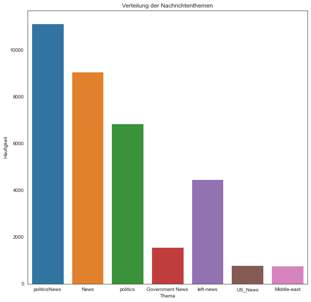

```python
newscompletedataset['subject'].value_counts()
plt.figure(figsize = (10,10))
sns.set_style('white')
sns.countplot(newscompletedataset['subject'])
plt.title('Verteilung der Nachrichtenthemen')
plt.ylabel('Häufigkeit')
plt.xlabel('Thema')
```

Es gibt Nachrichten zu 7 Themen. Die größte Anzahl von Nachrichten stammt aus der Kategorie `politicsNews`.

#### 6.4 Länge der Nachrichten

Wir wollen uns die Länge der einzelnen Nachrichten anschauen um Aussagen über deren Aussagekraft treffen zu können.

##### Schritt 1: Zählen der Länge jedes Feeds

Hierfür werden alle Zeichen innerhalb eines Newsfeed gezählt und dem Datensatz angehängt.

```python
def length_text(text):
        return len(text)

newscompletedataset['legth_text'] = newscompletedataset['text'].apply(length_text)
```

##### Schritt 2: Trennen des Datensatz nach Wahr und Falsch

```python
df_true = newscompletedataset[newscompletedataset['veracity'] == True]
df_false = newscompletedataset[newscompletedataset['veracity'] == False]
```

##### Schritt 3: Visualisierung

Bei der Visualisierung ist darauf zu achten, dass uns nur die durchschnittliche Länge sowie die Verteilung der % interessieren. Deshalb werden alle übrigen Spalten aus dem verwendeten Datensatz gelöscht.

```python
x = 'index'
y = 'legth_text'

rows = [0, 2, 3, 7]

df_true_describe = df_true.describe().reset_index().drop(rows)
df_false_describe = df_false.describe().reset_index().drop(rows)

options = dict(plot_width=500, plot_height=500,
               tools="pan,wheel_zoom,box_zoom,box_select,lasso_select,reset",)

g_news_length = figure(title='Länge der Sätze',x_range=df_true_describe[x], **options)
g_news_length.vbar(df_true_describe[x],bottom=0,top=df_true_describe[y],color="blue",width=0.8,alpha=0.6, legend_label="True")
g_news_length.vbar(df_false_describe[x],bottom=0,top=df_false_describe[y],color="red",width=0.8,alpha=0.6, legend_label="False")
g_news_length.xaxis.major_label_orientation = "vertical"
g_news_length.yaxis.formatter = BasicTickFormatter(use_scientific=False)

g_news_length.legend.orientation = "horizontal"
g_news_length.legend.location = "top_center"


show(g_news_length)
```

[interactive chart not shown]

##### Schritt 4: Interpretation

Es ist deutlich zu erkennen, dass die wahren Nachrichten im Durchschnitt sowie in allen Verteilungen länger sind. Dies kann ein deutlicher Indikator für die Klassifizierung sein.

Sollte die Anzahl der Zeichen in der nicht klassifizierten Nachricht mehr als 3000 Zeichen haben, so ist die Wahrscheinlichkeit größer, dass es sich eher um eine wahre Nachricht handelt als um eine falsche. Umgekehrt gilt natürlich das gleiche.

#### 6.5 Worthäufigkeiten

In diesem Schritt wird die Worthäufigkeit betrachtet um daraus Unterschiede zu erkennen.

##### Schritt 1: Worte identifizieren

Zum identifizieren der Worte kommt die Bibliothek `nltk` zum Einsatz. Sie bietet die Funktion `word_tokenize` und `FreqDist` an. Beides wird benötigt um als erstes einzelne tokens zu bilden und diese dann zusammenzufassen. Das Ergebnis ist ein Datenset welches die Häufigkeit der auftretenden Worte pro Zeile beinhaltet. Dies wird über das gesamte Datenset aggregiert. Dieser Vorgang wird in der Funktion `count_words` definiert.

Im Anschluss wird die Funktion auf die Daten angewendet.

```python
def count_words(df):
    # tokenize
    tokenize = df.apply(word_tokenize)
    # Count
    count_single_lines = tokenize.apply(FreqDist)

    # aggregieren
    end = {}
    for j in count_single_lines:
        for i in j:
            try:
                end[i] = end[i] + j[i]
            except:
                end[i] = j[i]

    return end
```

```python
all_words_true = count_words(df_true['text'])
all_words_false = count_words(df_false['text'])
```

##### Schritt 2: Löschen von Satzzeichen und unerwünschten Zeichen

`.` und `,` sollen zum Beispiel nicht als einzelne Worte gezählt werden, deshalb werden diese hier entfernt.

```python
remove = [',', '.', 's', ':', 'l', ';', '(', ')']

for key in remove:
    del all_words_true[key]
    del all_words_false[key]
```

##### Schritt 3: Die Top 40 Worte

Wir wollen uns die 40 häufigsten Worte anschauen. Dafür müssen diese aus dem bestehenden set extrahiert werden.

```python
true_top = Counter(all_words_true).most_common(40)
false_top = Counter(all_words_false).most_common(40)
```

Die Funktion dient hierbei zur Umwandlung der Daten aus einem `dict` zu einem pandas `DataFrame`. Um dies umzusetzen wird `key` und `count` separat in einer Liste ausgegeben. Dies erleichtert die Erstellung eines DataFrames.

```python
def get_key_count_df(liste):
    key = []
    count = []

    for i in liste:
        key.append(i[0])
        count.append(i[1])

    return key, count
```

```python
# True
key, count = get_key_count_df(true_top)

df_count_true = pd.DataFrame(data={'key': key, 'count': count})
df_count_true.head()
```

|  | key | count |
| --- | --- | --- |
| 0 | the | 975755 |
| 1 | to | 550241 |
| 2 | of | 497474 |
| 3 | a | 452165 |
| 4 | and | 448181 |

```python
# Fake
key, count = get_key_count_df(false_top)

df_count_false = pd.DataFrame(data={'key': key, 'count': count})
df_count_false.head()
```

|  | key | count |
| --- | --- | --- |
| 0 | the | 910610 |
| 1 | to | 510144 |
| 2 | of | 457733 |
| 3 | and | 413792 |
| 4 | a | 359308 |

##### Schritt 4: Visualisierung

```python
x = 'key'
y = 'count'

options = dict(plot_width=1000, plot_height=500,
               tools="pan,wheel_zoom,box_zoom,box_select,lasso_select,reset",)

g_word_count = figure(title='Anzahl der Worte',x_range=df_count_false[x], **options)
g_word_count.vbar(df_count_true[x],bottom=0,top=df_count_true[y],color="blue",width=0.8,alpha=0.6, legend_label="True")
g_word_count.vbar(df_count_false[x],bottom=0,top=df_count_false[y],color="red",width=0.8,alpha=0.6, legend_label="False")
g_word_count.xaxis.major_label_orientation = "vertical"
g_word_count.yaxis.formatter = BasicTickFormatter(use_scientific=False)

g_word_count.legend.orientation = "horizontal"
g_word_count.legend.location = "top_center"

show(g_word_count)
```

[interactive chart not shown]

##### Schritt 5: Interpretation

Es lässt sich deutlich erkennen, dass in den längeren wahren Nachrichten mehr Verbindungsworte wie z.B.: `the` enthalten sind. Weiter lässt sich folgendes sagen:

- `said` said steht für eine Erklärung was ein/e andere/r sagte und kann als Definition eines Beweises dienen. Die Grafik zeigt ein deutlich erhöhtes Vorkommen in den wahren Nachrichten.
- `?` Das Fragezeichen ist nur in den Top 40 der Fake News vertreten. Das bedeutet nicht, dass es in Wahren-Nachrichten nicht verwendet wird. Aber es hat keinen größeren Stellenwert im Vergleich zu den Fake News. Hierbei lässt sich die Aussage treffen, dass offene oder geschlossene Fragen bevorzugt in Fake News verwendet werden.
- `Trump` Zur Wahl der Präsidentschaft 2016 ging es hauptsächlich um Trump, wenn an Fake News gedacht wird. Es ist interessant zu sehen, dass dieser Name sehr ausgeglichen in wahren und falschen Nachrichten verwendet wird.

##### Schritt 6: Wordcloud

True News:

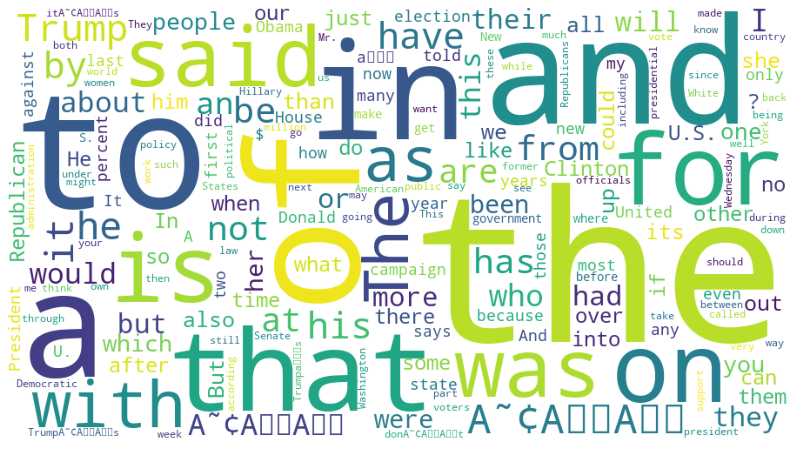

```python
plt.subplots(figsize = (18,8))
wordcloud_all_true = WordCloud(width=900, height=500, background_color='white').generate_from_frequencies(all_words_true)
plt.imshow(wordcloud_all_true)
plt.axis('off')
plt.show()
```

Fake News:

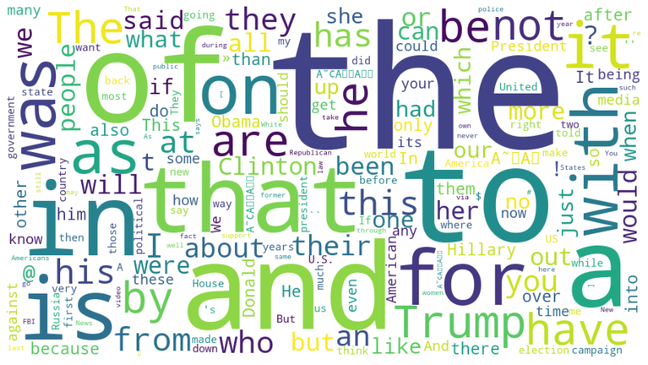

```python
plt.subplots(figsize = (18,8))
wordcloud_all_false = WordCloud(width=900, height=500, background_color='white').generate_from_frequencies(all_words_false)
plt.imshow(wordcloud_all_false)
plt.axis('off')
plt.show()
```

#### 6.6 Unterschiede zwischen wahren und falschen Nachrichten

##### Schritt 1: Berechnen der prozentuellen Differenz zwischen "wahr" und "falsch"

Um herauszufinden wo die Differenz zwischen wahr und falsch am größten ist, muss diese ausgerechnet werden. Hierfür werden beide Datensätze (wahr und falsch) nach ihren keys (das sind die Worte) durchsucht und die prozentuale Differenz ausgerechnet. Wichtig ist dabei, dass es für beide Sets gemacht wird damit auch Worte welche nur in einem Set vokommen, berücksichtigt werden. Das Ergebnis ist ein `dict` welches die Werte für die entsprechende Worte enthält.

```python
dif_dict = {}

for i in all_words_false:
    if i in all_words_true.keys():
        if all_words_false[i] > all_words_true[i]:
            g = all_words_true[i] / all_words_false[i]
        else:
            g = all_words_false[i] / all_words_true[i]
    else:
        g = 0

    dif_dict[i] = g

for i in all_words_true:
    if i in all_words_false.keys():
        if all_words_true[i] > all_words_false[i]:
            g = all_words_false[i] / all_words_true[i]
        else:
            g = all_words_true[i] / all_words_false[i]
    else:
        g = 0

    dif_dict[i] = g
```

##### Schritt 2: Level für die Visualisierung definieren

Um nicht von den Massen an Daten überflutet zu werden grenzen wir die Verteilung ein. Wir wollen nur Worte betrachten, welche in beiden Datensätzen vorkommen (> 0 sind) und welche eine große Differenz haben (Vorkommen der Daten < 0.2).

```python
dif = {}

for i in dif_dict:
    if dif_dict[i] < 0.2 and dif_dict[i] > 0:
        dif[i] = dif_dict[i]

len(dif)
```

```
12740
```

##### Schritt 3: Auswählen der Daten

Für die Auswertung wollen wir die Top 40 Worte betrachten.

```python
most_dif = Counter(dif).most_common(40)
```

Da wir für die Auswahl der Worte diese komplett zusammengelegt haben, ohne auf ihre Zugehörigkeit zu wahren- oder falschen Nachrichten zu achten, muss die Liste der Worte nun aus den Original sets entnommen und in einem neuen DataFrame dargestellt werden.

```python
dif_true = {}
dif_false = {}

for i, j in most_dif:
    dif_true[i] = all_words_true[i]
    dif_false[i] = all_words_false[i]
```

True:

```python
# Wahr
key = []
count = []

for i in dif_true:
    key.append(i)
    count.append(dif_true[i])

dif_count_true = pd.DataFrame(data={'key': key, 'count': count})
dif_count_true.head()
```

|  | key | count |
| --- | --- | --- |
| 0 | Rich | 165 |
| 1 | Presidency | 65 |
| 2 | amounted | 477 |
| 3 | RomneyÃ¢ÂÂs | 196 |
| 4 | essays | 151 |

Fake:

```python
# Fake
key = []
count = []

for i in dif_false:
    key.append(i)
    count.append(dif_false[i])

dif_count_false = pd.DataFrame(data={'key': key, 'count': count})
dif_count_false.head()
```

|  | key | count |
| --- | --- | --- |
| 0 | Rich | 826 |
| 1 | Presidency | 326 |
| 2 | amounted | 95 |
| 3 | RomneyÃ¢ÂÂs | 39 |
| 4 | essays | 30 |

##### Schritt 4: Visualisierung

```python
x = 'key'
y = 'count'

options = dict(plot_width=1000, plot_height=500,
               tools="pan,wheel_zoom,box_zoom,box_select,lasso_select,reset",)

g_diff_words = figure(title='Größte differenz in Worten',x_range=dif_count_false[x], **options)
g_diff_words.vbar(dif_count_true[x],bottom=0,top=dif_count_true[y],color="blue",width=0.8,alpha=0.6, legend_label="True")
g_diff_words.vbar(dif_count_false[x],bottom=0,top=dif_count_false[y],color="red",width=0.8,alpha=0.6, legend_label="False")
g_diff_words.xaxis.major_label_orientation = "vertical"
g_diff_words.yaxis.formatter = BasicTickFormatter(use_scientific=False)

g_diff_words.legend.orientation = "horizontal"
g_diff_words.legend.location = "top_center"

show(g_diff_words)
```

[interactive chart not shown]

##### Schritt 5: Interpretation

Es sind einige Indikatoren zu erkennen:

- `Rich`, `Congressman`, `Presidency` und `Resistance` kommt verhältnissmäßig häufig in falschen Nachrichten vor. Kommen diese Worte häufig in Verbindung miteinander in einer Nachricht vor, lässt dies auf eine mögliche Falschnachricht schließen.
- `essays` Das Wort steht übersetzt für eine Auseinandersetzung mit einem wissenschaftlichen Sachverhalt oder eines literarischen Themas (Duden). Daraus lässt sich schließen, dass die Verwendung von wissenschaftlichen Beweisen ein starker Indikator für wahre Nachrichten sind. Ebenso ist das Wort `benchmark` im Zusammenhang mit wissenschaftlichen Auswertungen ein starker Begriff und definiert einen Standart. Dieses Wort kommt verhältnissmäßig häufig in wahren Nachrichten vor. Das gleiche gilt auch für `procedural`.
- `amounted` interessant ist, dass die Mehrheit der wahren Nachrichten sich mit dem Wort `Betrug` befasst. Wir nehmen an, dass es sich hierbei um die Widerlegung von falschen Nachrichten handelt.

#### 6.7 Welche Worte kommen nur in falschen Nachrichten vor?

##### Schritt 1: Finden aller Worte welche nur in Fake News vokommen

Hier wird das Fake News Set betrachtet und Wörter identifiziert, welche nicht in den wahren Nachrichten vorkommen.

```python
fake_dict = {}

for i in all_words_false:
    if i not in all_words_true.keys():
        fake_dict[i] = all_words_false[i]
```

##### Schritt 2: Top 1000

Es werden die Top 1000 betrachtet, weil im nächsten Schritt weitere Bereinigungen folgen.

```python
most_fake = Counter(fake_dict).most_common(1000)
```

##### Schritt 3: Bereinigung

In manchen Worten ist noch ein Stück HTML enthalten. Diese Worte werden nicht benötigt. Durch das Tokenizen befinden sich hier noch Unicode-Reste. Diese müssen vom Datensatz entfernt werden. Das passiert indem die Worte in ein byte-Format transformiert werden und nach einem unicode typischen Aufbau gesucht und herausgefiltert wird.

```python
only_fake = {}

for i, j in most_fake:
    byte = bytes(i, 'utf-8')
    if b'\x82' not in byte:
        only_fake[i] = j
```

##### Schritt 4: Visualisierung durch Wordcloud

[figure not shown]

```python
plt.subplots(figsize = (18,8))
wordcloud_fake_news_only = WordCloud(width=900, height=500, background_color='white').generate_from_frequencies(only_fake)
plt.imshow(wordcloud_fake_news_only)
plt.axis('off')
plt.show()
```

##### Schritt 5: Interpretation

- Überraschend ist, dass zum Beispiel das Wort `quot` nur in falschen Nachrichten verwendet wird. Hier würde man annehmen, dass auch wahre Nachrichten das Wort verwenden da in vorherigen Schritten analysiert wurde, dass wahre Nachrichten sich häufiger mit der Beweisführung ihrer Aussagen befassen.
- Ebenfalls ist zu erkennen, dass sich Fake News mit dem Begriff der `Antifa` befassen. Antifa (Akronym für Antifaschistische Aktion) scheint in diesem Zusammenhang in allen verwendeten Zusammenhängen falsch interpretiert zu werden oder zweckentfremdete Verwendungen findet.

#### 6.8 N-Gramm-Ranking

Ein n-Gramm ist eine Folge von n Wörtern, wobei n eine diskrete Zahl ist, die von 1 bis unendlich reichen kann. Beim N-Gramm-Ranking werden die N-Gramme danach geordnet, wie oft sie in der Sammlung der Fake Nachrichten und True Nachrichten vorkommen.

##### Schritt 1: Berechnen der N-Gramms

Mit dem folgenden Code werden mit Hilfe der NLTK Bibliothek 2 Gramme sowie auch 3 Gramme gebildet und nach der Häufigkeit absteigend sortiert. Die häufigsten 10 n-Gramme der True-Nachrichten sowie auch der Fake-Nachrichten werden betrachtet.

```python
twograms_true=(pd.Series(nltk.ngrams(dataset_true_extend,2)).value_counts())[:10]
trigrams_true=(pd.Series(nltk.ngrams(dataset_true_extend,3)).value_counts())[:10]
twograms_false=(pd.Series(nltk.ngrams(dataset_false_extend,2)).value_counts())[:10]
trigrams_false=(pd.Series(nltk.ngrams(dataset_false_extend,3)).value_counts())[:10]
```

##### Schritt 2: Visualisierung

Der folgende Code zeigt die Visualisierung der häufigsten 10 n-Gramme als Balkendiagramm. Auf der Y-Achse sind die n-gramms gelistet und auf der X-Achse ist die Anzahl der Vorkommnisse aufgezeigt. Die Darstellung zeigt die 10 häufigsten 2 gramms und darauffolgend die 10 häufigsten 3 grams.

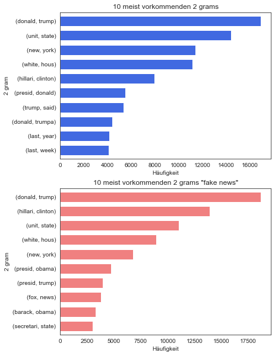

```python
plt.figure(figsize=(30,20))
sns.set_style('white')

plt.subplot(2,2,1)
twograms_true.sort_values().plot.barh(color='royalblue', width=.7, figsize=(14, 10))
plt.title('10 meist vorkommenden 2 grams')
plt.ylabel('2 gram')
plt.xlabel('Häufigkeit')

plt.subplot(2,2,3)
twograms_false.sort_values().plot.barh(color='lightcoral', width=.7, figsize=(14, 10))
plt.title('10 meist vorkommenden 2 grams "fake news"')
plt.ylabel('2 gram')
plt.xlabel('Häufigkeit')
```

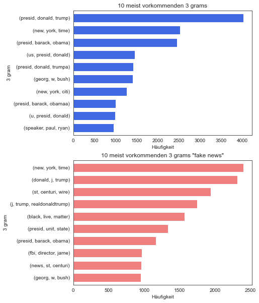

```python
plt.figure(figsize=(30,20))
sns.set_style('white')

plt.subplot(2,2,1)
trigrams_true.sort_values().plot.barh(color='royalblue', width=.7, figsize=(14, 10))
plt.title('10 meist vorkommenden 3 grams')
plt.ylabel('3 gram')
plt.xlabel('Häufigkeit')

plt.subplot(2,2,3)
trigrams_false.sort_values().plot.barh(color='lightcoral', width=.7, figsize=(14, 10))
plt.title('10 meist vorkommenden 3 grams "fake news"')
plt.ylabel('3 gram')
plt.xlabel('Häufigkeit')
```

##### Schritt 3: Interpretation

Fünf der gelisteten 2-grams kommen sowohl bei den Fake-Nachrichten als auch in den True-Nachrichten vor (Dobald, trump; hillari, clinton; unit, state; white-house; new, york). Die Häufigkeit varriiert, dies könnte auf die Verteilung zwischen True und False im Datensatz zurückgeführt werden. Da es sich um Amerikanische Nachrichten mit der Hauptkategorie der Politik handelt, sind die Wörter nicht auffallend. Es kann hieraus zwar die Relevanz der Gesprächsthemen abgeleiten werden aber nicht, ob es sich dadurch um ein Muster handelt. Analog dem Resultat aus der Analyse der Worthäufigkeiten ist zu erkennen, dass das Wort `said` sehr häufig in den wahren Nachrichten vorkommt. Am Häufigsten in Verbindung mit `trump`. Die Wahrscheinlichkeit, dass es sich um wahre Nachrichten handelt nimmt bei Auftreten der Kombination `Trump said`zu.

Auch die genaure Betrachtung der 3-grams zeigt kein auffälliges Muster auf. Sowohl in den Wahren-Nachrichten als auch in den Falschen-Nachrichten kommen viele Named Entities vor (z.B.: `new york time`, `white house`).

#### 6.9 Assoziationsregeln

Die Assoziationsregel ist eine Technik zur Identifikation von Beziehungen zwischen verschiedenen Elementen (z.B.: Wörtern).

Dieses Analyseverfahren wird angewendet um Rückschlüsse daraus zu ziehen, wie häufig und mit welcher Wahrscheinlichkeit bestimmte Wörter auftreten, wenn ein bestimmtes Wort/Kombination aus Wörtern in einem Artikel vorkommt.

Itemset = Wort oder auch Kombination aus Wörtern

Support-Wert = Anzahl des Vorkommens eines Itemsets in Relation zur Gesamtanzahl des Datensatzes.

##### Schritt 1: Bildung von Assoziationen und Analyse

Assoziationen können mit Hilfe von unterschiedlichen Formeln berechnet werden. In diesem Projekt wird der Apriori-Algorithmus verwendet. Er dient der Auffindung sinnvoller und nützlicher Zusammenhänge in Datenbasen, die in Form von Assoziationsregeln dargestellt werden.

Um nicht von den Massen an Daten überflutet zu werden, wird der Schwellenwert für den Support auf minimum 0,2 gesetzt.

##### True News:

```python
te = TransactionEncoder()# Mit dem TransactionEncoder-Objekt wird der Datensatz in ein Array-Format umwandeln
te_ary = te.fit(dataset_true).transform(dataset_true)# Über die fit-Methode lernt der TransactionEncoder die eindeutigen Bezeichnungen im Datensatz
df = pd.DataFrame(te_ary, columns=te.columns_)

frequent_itemsets_true = apriori(df, min_support=0.2, use_colnames=True)# min support = Schwellenwert für Support

print(frequent_itemsets_true.sort_values(by=['support'], ascending=False))
```

```
       support                             itemsets
115   0.817502                               (said)
159   0.641735                              (would)
91    0.573530                                (one)
4     0.567653                               (also)
144   0.565053                                 (us)
...        ...                                  ...
2193  0.200057            (would, also, call, said)
1531  0.200021                (donald, state, unit)
2212  0.200021             (would, one, make, also)
1146  0.200021                  (new, donald, also)
2445  0.200021  (would, trump, presid, state, said)

[2446 rows x 2 columns]
```

Das Ergebnis zeigt pro itemset den dazugehörigen Support-Wert. Das Wort "said" tritt in 81% der True-Nachrichten auf. Die Kombination aus den Wörtern "trump, presid, said, state, would" tritt in 20% der Nachrichten auf. Dieses Item-Set befindet sich knapp über dem Schwellenwert.

Um nach der Itemset-Länge filtern zu können, wird im folgenden Schritt diese Information als Spalte ergänzt.

```python
frequent_itemsets_true["itemset_len"] = frequent_itemsets_true["itemsets"].apply(lambda x: len(x))
print(frequent_itemsets_true)
```

```
       support                              itemsets  itemset_len
0     0.300638                              (accord)            1
1     0.246679                                  (ad)            1
2     0.234676                           (administr)            1
3     0.204046                               (allow)            1
4     0.567653                                (also)            1
...        ...                                   ...          ...
2441  0.200912     (would, trump, said, say, donald)            5
2442  0.221177   (would, trump, state, said, donald)            5
2443  0.201695  (would, trump, said, donald, trumpa)            5
2444  0.207750      (would, trump, us, said, donald)            5
2445  0.200021   (would, trump, presid, state, said)            5

[2446 rows x 3 columns]
```

Es kommt aufgrund des Schwellenwerts von 0,2 maximal eine Kombination aus 5 Wörtern vor.

Im nächsten Schritt wird die Kombination aus 2 Wörtern genauer betrachtet:

```python
association_item2= frequent_itemsets_true[ (frequent_itemsets_true['itemset_len'] == 2)] #  Filter 2er Kombi
association_item2= association_item2.sort_values(by=['support'], ascending=False) #  Sortieren nach Support
association_item2 = association_item2[:10] # Top 10 2er Kombinationen
print(association_item2)

test= association_item2["itemsets"]
```

```
       support         itemsets  itemset_len
1003  0.550664    (would, said)            2
445   0.506999  (donald, trump)            2
921   0.491078   (presid, said)            2
978   0.480678    (state, said)            2
991   0.479360       (us, said)            2
209   0.477188     (also, said)            2
987   0.471311    (trump, said)            2
854   0.461873      (one, said)            2
438   0.460697   (donald, said)            2
1004  0.457385     (year, said)            2
```

Die Kombination aus `would` und `said` kommt in fast 55% der True-Nachrichten vor. Die Kombination aus `Donald` und `Trump` zeigt einen Support-Wert von ca. 50 %. Es ist ersichtlich, dass das Wort `said` in 9 der top 10 zweier-Kombinationen vorkommt.

Im nächsten Schritt wird die Kombination aus 3 Wörtern genauer betrachtet:

```python
association_item3= frequent_itemsets_true[ (frequent_itemsets_true['itemset_len'] == 3)] #  Filter 3er Kombi
association_item3= association_item3.sort_values(by=['support'], ascending=False) #  Sortieren nach Support
association_item3 = association_item3[:10] # Top 10 3er Kombinationen
print(association_item3)
```

```
       support                 itemsets  itemset_len
1521  0.439969    (donald, trump, said)            3
1501  0.402856  (donald, presid, trump)            3
2045  0.374541    (said, presid, trump)            3
1497  0.372689   (donald, presid, said)            3
1271  0.359298      (would, also, said)            3
2052  0.354596    (would, presid, said)            3
1545  0.353243   (would, donald, trump)            3
2115  0.352637     (would, state, said)            3
2154  0.345585      (would, year, said)            3
1972  0.344944       (would, one, said)            3
```

Die genauere Betrachtung der Kombinationen auf vierer und fünfer Items zeigen keine neuen Muster auf.

```python
#4er Kombinationen
association_item4= frequent_itemsets_true[ (frequent_itemsets_true['itemset_len'] == 4)]
association_item4= association_item4.sort_values(by=['support'], ascending=False)
association_item4 = association_item4[:10]
# 5er Kombinationen
association_item5= frequent_itemsets_true[ (frequent_itemsets_true['itemset_len'] == 5)]
association_item5= association_item5.sort_values(by=['support'], ascending=False)
association_item5 = association_item5[:10]
```

##### Fake News

Im nächsten Schritt werden die Assoziationen auf Basis der Falsch-Nachrichten gebildet und analysiert.

```python
te = TransactionEncoder() # Mit dem TransactionEncoder-Objekt wird der Datensatz in ein Array-Format umwandeln
te_ary = te.fit(dataset_false).transform(dataset_false) # Über die fit-Methode lernt der TransactionEncoder die eindeutigen Bezeichnungen im Datensatz
df = pd.DataFrame(te_ary, columns=te.columns_)


frequent_itemsets_false = apriori(df, min_support=0.2, use_colnames=True)  # min support = Schwellenwert für Support
frequent_itemsets_false["itemset_len"] = frequent_itemsets_false["itemsets"].apply(lambda x: len(x))
print(frequent_itemsets_false.sort_values(by=['support'], ascending=False)) # Sortieren nach Support
```

```
      support                 itemsets  itemset_len
46   0.509680                    (one)            1
56   0.489067                   (said)            1
47   0.469108                  (peopl)            1
32   0.468618                   (like)            1
80   0.449775                  (would)            1
..        ...                      ...          ...
115  0.201198             (get, trump)            2
160  0.201144              (want, one)            2
94   0.200762             (call, said)            2
25   0.200681                   (help)            1
202  0.200163  (donald, presid, trump)            3

[204 rows x 3 columns]
```

Es ist zu erkennen, dass das Wort `said` in den Fake-Nachrichten mit 0.48 einen deutlich geringeren Support-Wert aufzeigt als in den True-Nachrichten. Die Kombination aus den Wörtern `donald`,`trump`und`presid` tritt in 20% der Fake-Nachrichten auf. Dieses Item-Set befindet sich knapp über dem Schwellenwert. Es kommt aufgrund des Schwellenwerts von 0,2 maximal eine Kombination aus 3 Wörtern vor.

Im nächsten Schritt wird die Kombination aus 2 Wörtern genauer betrachtet:

```python
association_item_2_false= frequent_itemsets_false[ (frequent_itemsets_false['itemset_len'] == 2)]
association_item_2_false= association_item_2_false.sort_values(by=['support'], ascending=False)
association_item_2_false_10= association_item_2_false[:10]
print(association_item_2_false_10)
```

```
      support         itemsets  itemset_len
99   0.323812  (donald, trump)            2
128  0.304071      (like, one)            2
149  0.301784     (one, peopl)            2
152  0.300585      (one, said)            2
161  0.294758     (would, one)            2
129  0.285146    (like, peopl)            2
156  0.284983      (one, time)            2
184  0.282560    (would, said)            2
164  0.279564    (peopl, said)            2
137  0.274854    (would, like)            2
```

Die Kombination aus `donald` und `trump` kommt in fast 33% der Fake-Nachrichten vor. Die Kombination aus `one` und `like` weist einen Support Wert von ca. 30 % auf. Das Wort `one` kommt dabei in 5 der 10 häufig vorkommenden 2er-Kombinationen vor.

Im nächsten Schritt wird die Kombination aus 3 Wörtern genauer betrachtet:

```python
association_item_3_false= frequent_itemsets_false[ (frequent_itemsets_false['itemset_len'] == 3)]
association_item_3_false= association_item_3_false.sort_values(by=['support'], ascending=False)
print(association_item_3_false)
```

```
      support                 itemsets  itemset_len
203  0.202097       (like, one, peopl)            3
202  0.200163  (donald, presid, trump)            3
```

Aufgrund des Schwellenwerts von 0.2 treten nur zwei Itemssetz mit einer 3er Kombination auf. Die Wortkombinationen zeigen keine weiteren Mustern auf.

##### Schritt 2: Visualisierung

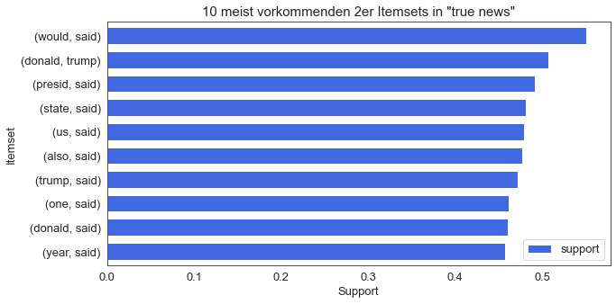

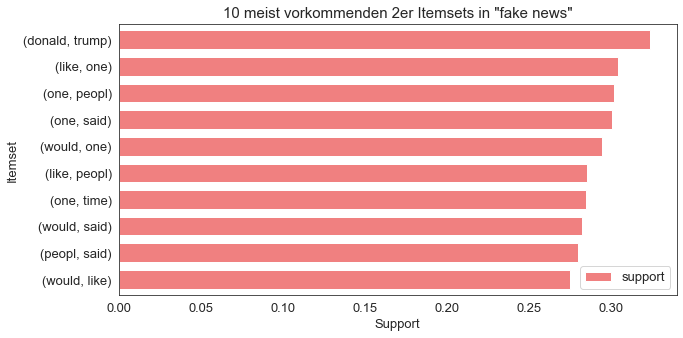

```python
plt.rcParams['font.size'] = '13'

association_item2.sort_values(by="support").plot.barh('itemsets','support',color='royalblue',width=.7, figsize=(10, 5))
plt.title('10 meist vorkommenden 2er Itemsets in "true news"',size=(15))
plt.ylabel('Itemset')
plt.xlabel('Support')

association_item_2_false_10.sort_values(by="support").plot.barh('itemsets','support',color='lightcoral',width=.7, figsize=(10, 5))
plt.title('10 meist vorkommenden 2er Itemsets in "fake news"',size=(15))
plt.ylabel('Itemset')
plt.xlabel('Support')
```

##### Schritt 3: Interpretation

Auch nach der Analyse der Assoziationen lässt sich erkennen, dass das Wort `said` ein Indiz für wahre Nachrichten sein kann. Es ist zu erkennen, dass in wahren Nachrichten das Wort `said` in 9 von 10 der häufig vorkommenden zweier-Kombinationen vorkommt. Bereits in der Analyse der Worthäufigkeiten in Abschnitt 6.5 konnte in den wahren Nachrichten ein deutlich erhöhtes Vorkommen des Wortes `said` ermittelt werden. Die Wörter `donald` und `trump` kommen sowohl bei den Fake-Nachrichten als auch bei den wahren Nachrichten vor. Da es sich um amerikanische Nachrichten mit der Hauptkategorie der Politik handelt, sind die Wörter nicht weiter auffallend.

### 7. Interpretation

Im folgenden Kapitel werden die Analyseergebnisse zusammengefasst und gegenübergestellt. Es ist wichtig zu erwähnen, dass die von uns gesammelten Erkenntnisse je nach Datensatz varriieren. In anderen Datensätzen, mit Nachrichten zum Beispiel aus anderen Ländern, können ggf. weitere Merkmale/Besonderheiten identifiziert werden.

Diese Key Indikatoren werden in der folgenden Grafik "Übersicht Erkenntnisse" dargestellt.

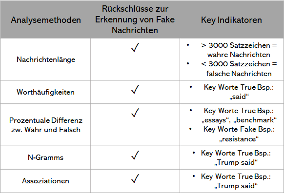

Durch die Analyse der Worthäufigkeit und der prozentualen Differenz zwischen "wahr" und "falsch" lässt sich erkennen, dass es Key Worte gibt welche in ihrer Häufigkeit und prozentualen Unterscheidung für eine Art der Klassifikation steht. Zum Beispiel kommt das Wort `said` häufiger in wahren Nachrichten vor. Ebenfalls stehen Worte wie `essays` und `benchmark` für wahre Nachrichten. Als Interpretation kann man hier die Annahme treffen, dass der Autor sich auf wissenschaftliche Beweise referenziert was somit in der Bedeutung der Nachricht für einen wahren Hintergrund spricht. Im Gegensatz dazu steht das Wort `resistance` eher für Fake Nachrichten. Betrachtet man ein ausgleichendes Verhältnis von Worten so trifft dies auf das Wort `trump` zu.

Auch durch die Analyse der Assoziationen lässt sich erkennen, dass das Wort `said` ein Indikator für wahre Nachrichten sein kann. Das Wort `said` tritt in 81% der True-Nachrichten auf und untermauert ebenfalls damit die Erkenntisse aus der Analyse der Worthäufigkeit. Aus der Betrachtung der zweier Wortkombinationen lässt sich ebenfalls erkennen, dass die Kombination aus `trump, said` häufiger in den wahren Nachrichten im Vergleich zu den Fake-Nachrichten vorkommt. Betrachtet man die Ergebnisse der Kombination aus `trump`und `said` in den True als auch Fake-Nachrichten, so ist ein deutlicher Unterschied zu erkennen. Die Ergebnisse der Assoziationsanalyse bestärkern damit auch die Erkenntnise der N-Gramm Analyse.

Assoziationsanalyse:

True-Nachricht:

```python
print(association_item2[6:7])
```

```
      support       itemsets  itemset_len
987  0.471311  (trump, said)            2
```

Fake-Nachricht

```python
print(association_item_2_false[19:20])
```

```
     support       itemsets  itemset_len
182   0.2571  (said, trump)            2
```

### 8. Ausblick

Der nächste Schritt, der sich aus der vorliegenden Arbeit entwickeln, ist die Betrachtung unterschiedlicher Lernalgorithmen, welche die automatisierte Einteilung der Nachrichten in "Fake" und "True" steuern. Dies könnte beispielsweise ein Klassifikationsalgorithmus sein, welcher versucht aus den vorliegenden gelabelten Nachrichten eine automatisierte Klassifikation zu erstellen.